# Discriminating evolution of acute myeloid leukaemia from age-related clonal haematopoiesis

```r
los <- do.call("rbind",mclapply(levels(samples), function(l){
  i <- samples!=l
  f <<- coxph(allSurv ~ ., data=d, subset=i)
  p <- as.matrix(d[!i,]) %*% f$coefficients
  r <- cbind(matrix(f$coefficients, nrow=length(p), ncol=length(f$coefficients), byrow=TRUE), linear.predictor=p)
  colnames(r) <- c(names(f$coefficients), "linear.predictor")
  as.data.frame(r)
}, mc.cores=4))
psGenes <- los[order(order(samples)),]

survConcordance(allSurv ~ psGenes$linear.predictor)
```

```
## Call:
## survConcordance(formula = allSurv ~ psGenes$linear.predictor)
##
##   n= 950
## Concordance= 0.7799296 se= 0.02746327
## concordant discordant  tied.risk  tied.time   std(c-d)
##  59805.000  16875.000      0.000      1.000   4211.768
```

Dynamic/cumulative AUC

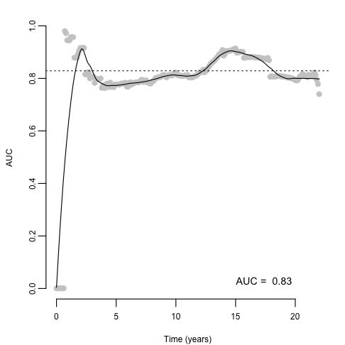

```r
auc.uno <- AUC.uno(survAll2, survAll2, psGenes$linear.predictor[w], times=t)

plot(auc.uno$times, auc.uno$auc, xlab="Time (years)", ylab="AUC", pch=16, col="grey80", ylim = c(0,1.0))
lines(auc.uno$times, predict(loess(auc.uno$auc ~ auc.uno$times, span=0.25)))
abline(h=auc.uno$iauc, lty = 3, lwd = 1)
legend("bottomright", bty = "n", cex = 1.2, legend = paste("AUC = ",round(auc.uno$iauc,2)))
```

```r
Genes.a <- auc.uno

# Concordance summary
c <- rbind(
  `(1) Any mutations`=as.data.frame(survConcordance(allSurv ~ psAnyMt$linear.predictor)[c("concordance","std.err")]),
  `(2) Any mt + VAF`=as.data.frame(survConcordance(allSurv ~ psAnyMtVaf$linear.predictor)[c("concordance","std.err")]),
  `(3) No. mt + cumulative VAF`=as.data.frame(survConcordance(allSurv ~ psNMtCumVaf$linear.predictor)[c("concordance","std.err")]),
  `(4) Gene model`=as.data.frame(survConcordance(allSurv ~ psGenes$linear.predictor)[c("concordance","std.err")]))

c
```

|  | concordance | std.err |
| --- | --- | --- |
| (1) Any mutations | 0.5431925 | 0.02388586 |
| (2) Any mt + VAF | 0.7287559 | 0.02388730 |
| (3) No. mt + cumulative VAF | 0.7433620 | 0.02388730 |
| (4) Gene model | 0.7799296 | 0.02746327 |

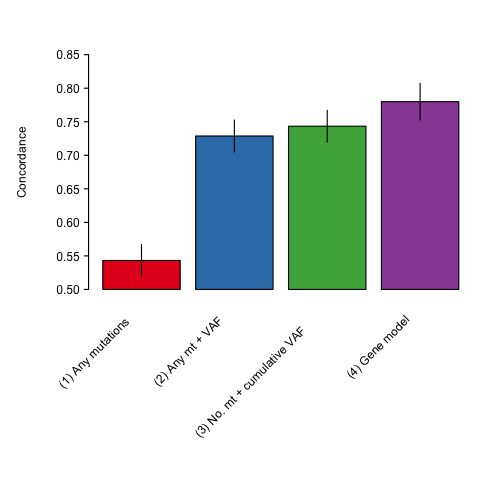

```r
set1 <- RColorBrewer::brewer.pal(6,"Set1")

par(mar = c(9, 4, 1.5, 0.5) + 0.1, mgp=c(2.7,0.4,0), las=1, tcl=-0.2)
b <- barplot(c$concordance-0.5, ylab="Concordance", col=set1, ylim=c(0.5,0.88), offset=0.5)
mg14::rotatedLabel(x=b, labels=rownames(c))
segments(b,c$concordance+c$std.err,b,c$concordance-c$std.err)
```

Dynamic/cumulative AUC summary

```r
d.auc <- data.frame(iauc = c(AnyMt.a$iauc, AnyMtVaf.a$iauc, NMtCumVaf.a$iauc, 0.79))
rownames(d.auc) <- c("(1) Any mutations", "(2) Any mt + VAF", "(3) No. mt + cumulative VAF", "(4) Gene model")

d.auc
```

|  | iauc |
| --- | --- |
| (1) Any mutations | 0.5528776 |
| (2) Any mt + VAF | 0.7420613 |
| (3) No. mt + cumulative VAF | 0.7618961 |
| (4) Gene model | 0.7900000 |

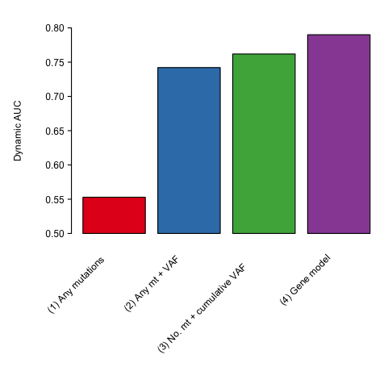

```r
par(mar = c(9, 4, 1.5, 0.5) + 0.1, mgp=c(2.7,0.4,0), las=1, tcl=-0.2)
b <- barplot(d.auc$iauc-0.5, ylab="Dynamic AUC", col=set1, ylim=c(0.5,0.80), offset=0.5)
mg14::rotatedLabel(x=b, labels=rownames(d.auc))
```

AML-free survival by number of drivers

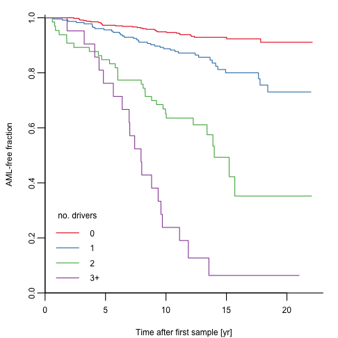

```r
nonc <- rowSums(allX[,allGroups=="Genes"]>0)
nonc <- cut(nonc, c(-1,0,1,2,max(nonc)))
plot(survfit(allSurv~nonc), col=set1, xlab='Time after first sample [yr]', ylab='AML-free fraction', bty='L', yaxs='i', ylim=c(0,1.01))
legend("bottomleft", c(0,1,2,"3+"), col=set1, lty=1, bty='n', title="no. drivers")
```

AML-free survival by max VAF

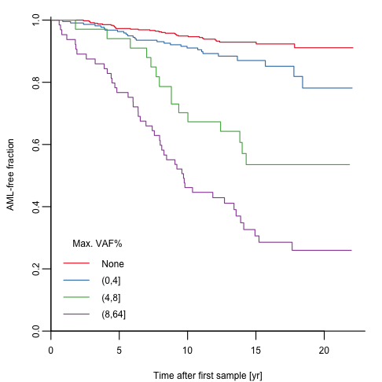

```r
mvaf <- apply(allX[,allGroups=="Genes"], 1, max)*10
mvaf <- cut(mvaf, c(-1,0,4,8,max(mvaf)))
plot(survfit(allSurv~mvaf), col=set1, xlab='Time after first sample [yr]', ylab='AML-free fraction', bty='L', yaxs='i', ylim=c(0,1.01))
levels(mvaf)[1] <- "None"
legend("bottomleft", levels(mvaf), col=set1, lty=1, bty='n', title="Max. VAF%")
```

# 8 Logistic regression

```r
library(glmnet)
library(ROCR)
```

## 8.1 Combined

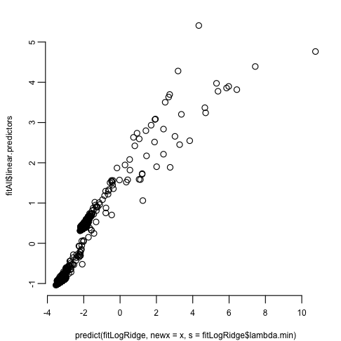

```r
set.seed(42)
y <- allSurv[,3]
x <- allX
x <- as.matrix(cbind(x, mu.Genes=rowSums(x[,allGroups=="Genes"])))
fitLogRidge <- cv.glmnet(x, y, alpha=0, standardize=FALSE, penalty.factor=c(allGroups=="Genes",FALSE), family="binomial", lambda=10^seq(-5,5,0.1)/nrow(x))
fitLog <- glm(y ~ x[,-ncol(x)], family="binomial")
coefLogRidge <- coef(fitLogRidge, s=fitLogRidge$lambda.min)[-1,1]
w <- names(coefLogRidge) %in% colnames(allX)[allGroups=="Genes"]
coefLogRidge[w] <- coefLogRidge[w] + coefLogRidge["mu.Genes"]
names(coefLogRidge) <- colnames(x)
s <- summary(survfit(allSurv ~1))

plot(predict(fitLogRidge, newx=x, s=fitLogRidge$lambda.min),fitAll$linear.predictors)
```

```r
cor(predict(fitLogRidge, newx=x, s=fitLogRidge$lambda.min),fitAll$linear.predictors)
```

```
##        [,1]
## 1 0.9325608
```

## 8.2 Discovery cohort

```r
set.seed(42)
x <- cbind(as.matrix(torontoX), mu.Genes=rowSums(torontoX[torontoGroups=="Genes"]))
fitLogRidgeToronto <- cv.glmnet(x, torontoSurv[,2], alpha=0, standardize=FALSE, penalty.factor=c(torontoGroups=="Genes",FALSE), family="binomial", lambda=10^seq(-5,5,0.1)/nrow(x))
l <- max(which(abs(fitLogRidgeToronto$cvm- min(fitLogRidgeToronto$cvm)) < 0.01))
coefFitLogRidgeToronto <- coef(fitLogRidgeToronto, s=fitLogRidge$lambda.min *nrow(allX)/nrow(torontoX))[-1,1]
w <- names(coefFitLogRidgeToronto) %in% colnames(torontoX)[torontoGroups=="Genes"]
coefFitLogRidgeToronto[w] <- coefFitLogRidgeToronto[w] + coefFitLogRidgeToronto["mu.Genes"]
```

## 8.3 Validation cohort

```r
set.seed(42)
x <- cbind(as.matrix(sangerX), mu.Genes=rowSums(sangerX[sangerGroups=="Genes"]))
y <- sangerSurv[,3]
fitLogRidgeSanger <- glmnet(x, y, alpha=0, standardize=FALSE, penalty.factor=c(sangerGroups%in%c("Genes","Blood"),1e-2) , family="binomial",lambda=10^seq(-5,5,0.1)/nrow(x))
coefFitLogRidgeSanger <- coef(fitLogRidgeSanger, s=fitLogRidge$lambda.min*nrow(allX)/nrow(sangerX)/4)[-1,1]
w <- names(coefFitLogRidgeSanger) %in% colnames(sangerX)[sangerGroups=="Genes"]
coefFitLogRidgeSanger[w] <- coefFitLogRidgeSanger[w] + coefFitLogRidgeSanger["mu.Genes"]
coefFitLogRidgeSanger
```

```
##   ASXL1_0.1     CBL_0.1  DNMT3A_0.1    JAK2_0.1   KMT2C_0.1   KMT2D_0.1    KRAS_0.1     NF1_0.1    NRAS_0.1   RAD21_0.1
##  1.61735484  0.62402794  0.60690505  1.21223108  1.28664688  0.38990853  1.30579768  1.05008349  1.12131863  1.08384807
##   SF3B1_0.1   SRSF2_0.1    TET2_0.1    TP53_0.1   U2AF1_0.1      age_10      gender  systol_100 diastol_100      bmi_10
##  0.95795153  0.76775960  0.87432787  2.09849607  2.46513749  0.15915519 -0.17104884 -0.26674155  0.40623412  0.78151214
## cholestl_10     triglyc         hdl         ldl         lym     mcv_100      rdw_10      wbc_10     plt_100      hgb_10
##  0.02221735 -0.02231645 -0.60655423  0.08051073  0.02388812 -0.48424380  1.43925261 -0.13343432  0.28531137  0.80105113
##    mu.Genes
##  1.16143798
```

## 8.4 Bootstrap CIs

```r
coefLogRidgeBoot <- sapply(1:100, function(foo){
            set.seed(foo)
            y <- allSurv[,3]
            x <- allX
            x <- as.matrix(cbind(x, mu.Genes=rowSums(x[,allGroups=="Genes"])))
            b <- sample(1:nrow(x), replace=TRUE)
            fitLogRidgeBoot <- glmnet(x[b,], y[b], alpha=0, standardize=FALSE, penalty.factor=c(allGroups=="Genes",FALSE, FALSE), family="binomial", lambda=10^seq(-5,5,0.1)/nrow(x))
            coefLogRidgeBoot <- coef(fitLogRidgeBoot, s=fitLogRidge$lambda.min)[-1,1]
            w <- names(coefLogRidgeBoot) %in% colnames(allX)[allGroups=="Genes"]
            coefLogRidgeBoot[w] <- coefLogRidgeBoot[w] + coefLogRidgeBoot["mu.Genes"]
            names(coefLogRidgeBoot) <- colnames(x)
            coefLogRidgeBoot
        })
```

## 8.5 Forest plot

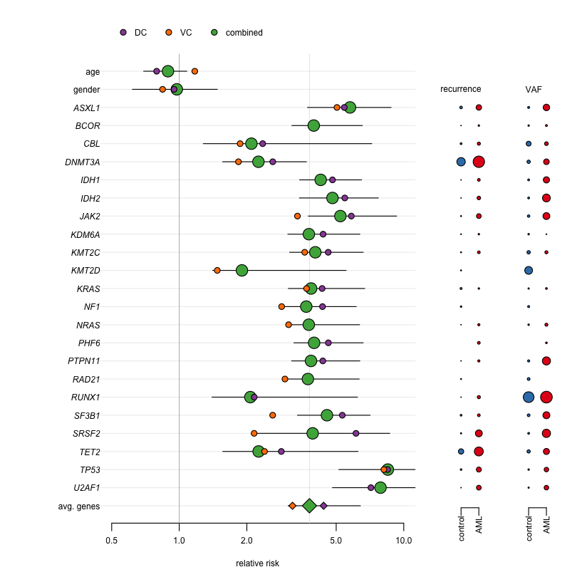

```r
par(bty="n", mar=c(3,6,3,10)+.5, mgp=c(2,0.5,0), xpd=FALSE)
c <- exp(coefLogRidge[-25])
o <- c(23:24,1:22,25)
ci <- apply(coefLogRidgeBoot,1,quantile, c(0.025,0.975))[,-25]
y <- rev(seq_along(c))
plot(c[o], y, xlab="relative risk", log='x', ylab='', yaxt="n", pch=NA, xlim=c(0.5,10))
abline(h=y, col="#EEEEEE", lty=1)
abline(v=1, lty=1, col="grey")
abline(v=c["mu.Genes"], col=mg14::colTrans(set1[3]), lty=1)
segments(exp(ci[1,o]), y, exp(ci[2,o]),y)
points(c[o], y, xlab="relative risk",  bg=set1[3], cex=2, pch=c(rep(21,24), 23))
m <- match(names(c)[o],names(coefFitLogRidgeToronto))
points(exp(coefFitLogRidgeToronto[m]), y,bg=set1[4], pch=c(rep(21,24), 23), cex=1)
m <- match(names(c)[o],names(coefFitLogRidgeSanger))
points(exp(coefFitLogRidgeSanger[m]), y,bg=set1[5], pch=c(rep(21,24), 23), cex=1)
mtext(side=2, sub("mu.Genes","avg. genes",sub("_.+","",names(c)[o])), at=y, las=2, font=c(1,1,rep(3,22),1))

r <- sapply(split(as.data.frame(allX>0), control), colMeans)
f <- sapply(split(allX, control), apply, 2, function(x) mean(x[x>0]))
par(xpd=NA)
points(rep(18,22),y[3:24], cex=sqrt(r[o[3:24],2]*10), pch=21, bg=set1[2])
points(rep(18*1.2,22), y[3:24], cex=sqrt(r[o[3:24],1]*10), pch=21, bg=set1[1])
points(rep(36,22),y[3:24], cex=sqrt(f[o[3:24],2]), pch=21, bg=set1[2])
points(rep(36*1.2,22), y[3:24], cex=sqrt(f[o[3:24],1]), pch=21, bg=set1[1])
legend(x=0.5, y=28, pch=21, pt.bg=set1[c(4,5,3)], c("DC","VC","combined"), bty="n", ncol=3, text.width=0.1)

text(y=24, x=18, "recurrence")
text(y=24, x=38, "VAF")

axis(1, at=c(18,18*1.2), c("control","AML"), las=2, line=-1)
axis(1, at=c(36,36*1.2), c("control","AML"), las=2, line=-1)
```

## 8.6 AUC

```r
aucLogRidgeBoot <- t(sapply(1:100, function(foo){
                    set.seed(foo)
                    y <- allSurv[,3]
                    x <- allX
                    x <- as.matrix(cbind(x, mu.Genes=rowSums(x[,allGroups=="Genes"])))
                    b <- sample(1:nrow(x), replace=TRUE)
                    oob <- setdiff(1:nrow(x),b)
                    c(inb=performance(prediction(x[b,] %*% coefLogRidgeBoot[,foo], y[b]),"auc")@y.values[[1]],
                            oob=performance(prediction(x[oob,] %*% coefLogRidgeBoot[,foo], y[oob]),"auc")@y.values[[1]])
                }))

apply(aucLogRidgeBoot, 2, quantile)
```

```
##            inb       oob
## 0%   0.7600825 0.7331746
## 25%  0.7981192 0.7814137
## 50%  0.8107881 0.8058353
## 75%  0.8228798 0.8254089
## 100% 0.8616209 0.8650056
```

```r
performance(prediction(as.matrix(torontoX) %*% coefFitLogRidgeToronto[-22], torontoSurv[,2]),"auc")@y.values[[1]]
```

```
## [1] 0.7649573
```

```r
performance(prediction(as.matrix(sangerImp) %*% coefFitLogRidgeToronto[-22], sangerSurv[,3]),"auc")@y.values[[1]]
```

```
## [1] 0.806366
```

```r
performance(prediction(as.matrix(sangerX) %*% coefFitLogRidgeSanger[-31], sangerSurv[,3]),"auc")@y.values[[1]]
```

```
## [1] 0.8479775
```

```r
performance(prediction(ImputeMissing(sangerX, as.matrix(torontoImp)) %*% coefFitLogRidgeSanger[-31], torontoSurv[,2]),"auc")@y.values[[1]]
```

```
## [1] 0.6885916
```

# 9 Tabulate results

```r
# library(xlsx)
# wb <- createWorkbook("xlsx")
# sheet  <- createSheet(wb, sheetName="Cox PH adjusted (combined)")
# addDataFrame(waldWeighted,
#       sheet,
#       colnamesStyle = CellStyle(wb) + Font(wb, isBold=TRUE) + Border(),
#       rownamesStyle = CellStyle(wb) + Font(wb, isBold=TRUE)
# )
# sheet  <- createSheet(wb, sheetName="Cox PH adjusted (DC)")
# addDataFrame(waldWeightedToronto,
#       sheet,
#       colnamesStyle = CellStyle(wb) + Font(wb, isBold=TRUE) + Border(),
#       rownamesStyle = CellStyle(wb) + Font(wb, isBold=TRUE)
# )
#
# sheet  <- createSheet(wb, sheetName="Cox PH adjusted (VC)")
# addDataFrame(waldWeightedSanger,
#       sheet,
#       colnamesStyle = CellStyle(wb) + Font(wb, isBold=TRUE) + Border(),
#       rownamesStyle = CellStyle(wb) + Font(wb, isBold=TRUE)
# )
#
# sheet  <- createSheet(wb, sheetName="Logistic regression (combined)")
# addDataFrame(data.frame(`Coef combined`=coefLogRidge, CI=t(apply(coefLogRidgeBoot, 1, quantile, c(0.025,0.975))),
#               check.names=FALSE),
#       sheet,
#       colnamesStyle = CellStyle(wb) + Font(wb, isBold=TRUE) + Border(),
#       rownamesStyle = CellStyle(wb) + Font(wb, isBold=TRUE)
# )
#
# sheet  <- createSheet(wb, sheetName="Logistic regression (DC)")
# addDataFrame(data.frame(`Coef combined`=coefFitLogRidgeToronto,
#               check.names=FALSE),
#       sheet,
#       colnamesStyle = CellStyle(wb) + Font(wb, isBold=TRUE) + Border(),
#       rownamesStyle = CellStyle(wb) + Font(wb, isBold=TRUE)
# )
# sheet  <- createSheet(wb, sheetName="Logistic regression (Sanger)")
# addDataFrame(data.frame(`Coef combined`=coefFitLogRidgeSanger,
#               check.names=FALSE),
#       sheet,
#       colnamesStyle = CellStyle(wb) + Font(wb, isBold=TRUE) + Border(),
#       rownamesStyle = CellStyle(wb) + Font(wb, isBold=TRUE)
# )
# saveWorkbook(wb, file="SupplementaryTables.xlsx")
```

# 10 Clinical/Demographic model

```r
f = "data/DC_vaf_matrix_no_duplicates_414ctrl_83aml.csv"
torontoData <- read.csv(f)

torontoData$gender <- ifelse(torontoData$Sex == "male", 1,
                             ifelse(torontoData$Sex == "female", 0, torontoData$Sex))
table(torontoData$gender)
```

```
##
##   0   1
## 293 204
```

```r
torontoData$gender <- as.numeric(torontoData$gender)
colnames(torontoData)
```

```
##  [1] "Sample"     "ASXL1"      "BCOR"       "CALR"       "CBL"        "DNMT3A"     "IDH1"       "IDH2"
##  [9] "JAK2"       "KDM6A"      "KIT"        "KMT2C"      "KRAS"       "NF1"        "NRAS"       "PHF6"
## [17] "PTPN11"     "RUNX1"      "SF3B1"      "SRSF2"      "TET2"       "TP53"       "U2AF1"      "Diagnosis"
## [25] "fu_years"   "age"        "Sex"        "no_drivers" "gender"
```

Manually standardize magnitudes

```r
torontoData <- torontoData[!duplicated(torontoData),]

gene_vars <- c("CALR", "NRAS", "DNMT3A", "SF3B1", "IDH1", "KIT", "TET2", "RAD21", "JAK2", "CBL", "KRAS", "PTPN11", "IDH2", "TP53", "NF1", "SRSF2", "CEBPA", "ASXL1", "RUNX1", "U2AF1", "BCOR", "KDM6A", "PHF6", "KMT2C", "KMT2D")

torontoX <- torontoData[, colnames(torontoData) %in% c(gene_vars, "age", "gender")]

torontoX <- as.data.frame(torontoX)
```

```r
thr <- 2
torontoX <- torontoX[,colSums(torontoX != 0)>=thr]

torontoGroups <- factor(names(torontoX) %in% c("age","gender")+1, level=1:2, labels=c("Genes","Demographics"))
colnames(torontoX)
```

```
##  [1] "ASXL1"  "CALR"   "CBL"    "DNMT3A" "IDH1"   "IDH2"   "JAK2"   "KDM6A"  "KMT2C"  "KRAS"   "NF1"    "PHF6"
## [13] "PTPN11" "RUNX1"  "SF3B1"  "SRSF2"  "TET2"   "TP53"   "U2AF1"  "age"    "gender"
```

```r
torontoGroups
```

```
##  [1] Genes        Genes        Genes        Genes        Genes        Genes        Genes        Genes
##  [9] Genes        Genes        Genes        Genes        Genes        Genes        Genes        Genes
## [17] Genes        Genes        Genes        Demographics Demographics
## Levels: Genes Demographics
```

Manually standardize age and mutation VAFs

```r
torontoX$age <- torontoX$age/10
names(torontoX)[which(names(torontoX)=="age")] <- "age_10"
g <- torontoGroups == "Genes"
torontoX[,g] <- torontoX[,g]*10
names(torontoX)[g] <- paste(names(torontoX)[g], "0.1",sep="_")
colnames(torontoX)
```

```
##  [1] "ASXL1_0.1"  "CALR_0.1"   "CBL_0.1"    "DNMT3A_0.1" "IDH1_0.1"   "IDH2_0.1"   "JAK2_0.1"   "KDM6A_0.1"
##  [9] "KMT2C_0.1"  "KRAS_0.1"   "NF1_0.1"    "PHF6_0.1"   "PTPN11_0.1" "RUNX1_0.1"  "SF3B1_0.1"  "SRSF2_0.1"
## [17] "TET2_0.1"   "TP53_0.1"   "U2AF1_0.1"  "age_10"     "gender"
```

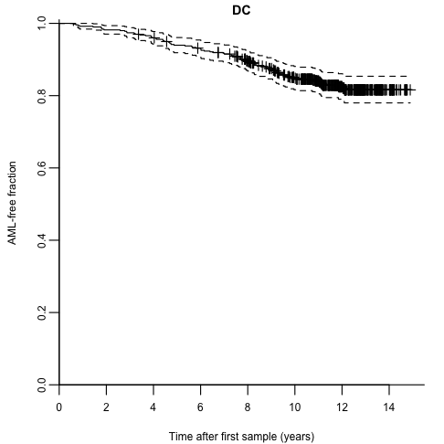

```r
torontoSurv <- Surv(torontoData$fu_years, torontoData$Diagnosis=="AML")
plot(survfit(torontoSurv~ 1), col= "black", main = "DC", xlab='Time after first sample (years)', ylab='AML-free fraction', bty='L', yaxs='i', ylim=c(0,1.01), mark.time = T)
```

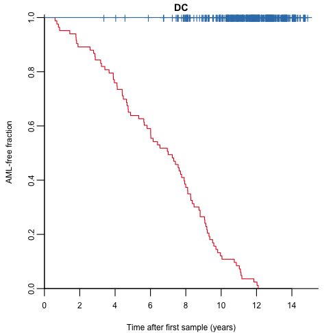

```r
plot(survfit(torontoSurv ~ torontoData$Diagnosis), xlab='Time after first sample (years)', main = "DC", ylab='AML-free fraction', bty='L', yaxs='i', ylim=c(0,1.01), mark.time = T, col = set1[1:2])
```

## 10.1 Validation cohort

all 37 pre-AML samples including overlap with DC

```r
f = "data/VC_vaf_matrix_262ctrl_37aml_nodates.csv"
sangerData <- read.csv(f)

sangerData$hcdate <- as.Date(sangerData$hcdate)
sangerData$dodx <- as.Date(sangerData$dodx)

sangerPatients <- sub("[a-z]+$","", sangerData$Sample)
o <- order(sangerPatients, as.numeric(sangerData$hcdate))

sangerData <- sangerData[o,]
sangerPatients <- sangerPatients[o]

clinical_vars <- c("systol", "diastol", "bmi", "cholestl", "triglyc", "hdl", "ldl", "lym", "mcv", "rdw", "wbc", "plt", "hgb")
sangerX <- sangerData[, colnames(sangerData) %in% c(gene_vars, "age","gender",clinical_vars)]
sangerX <- as.data.frame(sangerX)

sangerX <- sangerX[,colSums(sangerX != 0,na.rm=TRUE)>=thr]
sangerGroups <- factor(grepl("^[a-z]", colnames(sangerX))*2, levels=0:2, labels=c("Genes", "Demographics", "Blood"))
sangerGroups[names(sangerX) %in% c("age","gender")] <- "Demographics"
table(sangerGroups)
```

```
## sangerGroups
##        Genes Demographics        Blood
##           15            2           13
```

```r
colnames(sangerX)
```

```
##  [1] "ASXL1"    "CBL"      "DNMT3A"   "JAK2"     "KMT2C"    "KMT2D"    "KRAS"     "NF1"      "NRAS"     "RAD21"
## [11] "SF3B1"    "SRSF2"    "TET2"     "TP53"     "U2AF1"    "age"      "gender"   "systol"   "diastol"  "bmi"
## [21] "cholestl" "triglyc"  "hdl"      "ldl"      "lym"      "mcv"      "rdw"      "wbc"      "plt"      "hgb"
```

```r
sangerGroups
```

```
##  [1] Genes        Genes        Genes        Genes        Genes        Genes        Genes        Genes
##  [9] Genes        Genes        Genes        Genes        Genes        Genes        Genes        Demographics
## [17] Demographics Blood        Blood        Blood        Blood        Blood        Blood        Blood
## [25] Blood        Blood        Blood        Blood        Blood        Blood
## Levels: Genes Demographics Blood
```

```r
poorMansImpute <- function(x) {x[is.na(x)] <- mean(x, na.rm=TRUE); return(x)}
sangerX <- as.data.frame(sapply(sangerX, poorMansImpute))

foo <- split(sangerData[,c("Diagnosis","hcdate","dodx")], sangerPatients)

bar <- do.call("rbind",lapply(foo, function(x){
  y <- x
  n <- nrow(y)
  y[-n,"Diagnosis"] <- "Control"
  start <- as.numeric(y$hcdate - y$hcdate[1])/365.25
  end <- c(as.numeric(y$hcdate - y$hcdate[1])[-1]/365.25, as.numeric(y$dodx[n] - y$hcdate[1])/365.25)
  return(data.frame(Diagnosis=y[,"Diagnosis"], start=start, end=end))
}))

bar[1:10, ]
```

|  | Diagnosis | start | end |
| --- | --- | --- | --- |
| PD29762 | AML | 0.000000 | 9.754962 |
| PD29764 | AML | 0.000000 | 10.360027 |
| PD29792 | AML | 0.000000 | 14.108145 |
| PD29804 | Control | 0.000000 | 5.138946 |
| PD29810 | Control | 0.000000 | 18.573580 |
| PD29836.1 | Control | 0.000000 | 2.414784 |
| PD29836.2 | AML | 2.414784 | 10.023272 |
| PD29851.1 | Control | 0.000000 | 4.599589 |
| PD29851.2 | AML | 4.599589 | 12.205339 |
| PD29856.1 | Control | 0.000000 | 4.331280 |

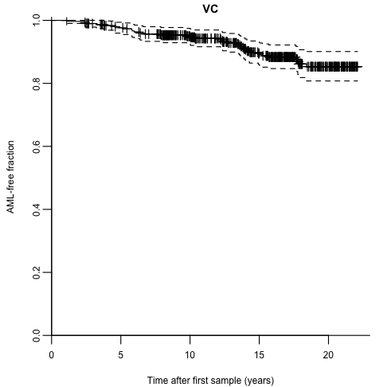

```r
sangerPatientsSplit <- unlist(sapply(names(foo), function(n) rep(n, nrow(foo[[n]]))))

sangerSurv <- Surv(time = bar$start, time2 = bar$end, event = bar$Diagnosis!="Control", origin = 0)

plot(survfit(sangerSurv~ 1), col= "black", main = "VC", xlab='Time after first sample (years)', ylab='AML-free fraction', bty='L', yaxs='i', ylim=c(0,1.01), mark.time = T) #mark = 1
```

Figure 3 c-e

```r
summary(sangerX$rdw)
```

```
##    Min. 1st Qu.  Median    Mean 3rd Qu.    Max.
##   11.40   13.10   13.42   13.42   13.42   22.00
```

```r
rdw <- cut(sangerX$rdw, c(11, 14, max(sangerX$rdw)))
levels(rdw) <- c("11-14", "14+")
table(rdw)
```

```
## rdw
## 11-14   14+
##   400    59
```

```r
selected_genes <- c("DNMT3A", "TET2", "TP53", "U2AF1")

png("./figures/CombinedCohorts.KM.selected.genes.png", width = 8.5, height = 17.5, units = "cm", res = 800)
par(mfrow=c(4,2), mar = c(1.9, 1.9, 1.7, 0.7) + 0.1, mgp=c(2.2,0.4,0), bty="L", xpd=TRUE, las=1, tcl=-0.15, cex.axis=1.15, cex.lab = 1)
for (i in 1:length(selected_genes)) {
  #i <- 1
  gene <- selected_genes[i]
  plot(survfit(surv ~ X[[gene]] == 0), col= pal1, bty='L', yaxs='i', ylim=c(0,1.01), mark.time = T, conf.int = F)
  mtext(gene, font=3, side = 3, line = 0.2, cex = 0.83)
  legend("bottomleft", col=pal1[1:2], lty=1, c("MT","WT"), lwd = 1.5, bty="n", ncol = 1, cex = 0.9, seg.len=0.7)
}
plot(survfit(surv ~ n_drivers), col=rev(pal1[1:3]), conf.int = F, mark.time = T, bty='L', yaxs='i', ylim=c(0,1.01))
mtext("Number of drivers", font=1, side = 3, line = 0.7, cex = 0.83)
legend("bottomleft", legend = levels(n_drivers), col= rev(pal1[1:3]), lty=1, lwd = 1.5, bty='n', title="", cex = 1, seg.len=0.7)
plot(survfit(surv ~ mvaf), col= rev(pal1[1:4]), conf.int = F, mark.time = T, bty='L', yaxs='i', ylim=c(0,1.01))
mtext("Maximum VAF (%)", font=1, side = 3, line = 0.7, cex = 0.83)
legend("bottomleft", levels(mvaf), col=rev(pal1[1:4]), lty=1, lwd = 1.5, bty='n', title="", cex = 1, seg.len=0.7)
plot(survfit(sangerSurv ~ rdw), col= rev(pal1[1:2]), conf.int = F, mark.time = T, bty='L', yaxs='i', ylim=c(0,1.01))
mtext("RDW", font=1, side = 3, line = 0.2, cex = 0.83)
legend("bottomleft", levels(rdw), col=rev(pal1[1:2]), lty=1, lwd = 1.5, bty='n', title="", cex = 1, seg.len=0.7)
dev.off()
```

Standardise magnitudes

```r
g <- sangerGroups=="Genes"
sangerX[g] <- sangerX[g] * 10
names(sangerX)[g] <- paste(names(sangerX[g]),"0.1", sep="_")
y <- StandardizeMagnitude(sangerX[!g])
sangerX <- cbind(sangerX[g],y)
```

## 10.2 Expected AML incidence

Validation cohort

```r
w <- c(which(sangerSurv[,1]==0)[-1]-1, nrow(sangerSurv))
sangerSurv2 <- Surv(sangerSurv[w,2], sangerSurv[w,3])

expected_rate_sanger_cr <- mean(aml_inc_cr(sangerX[w,"gender"],sangerX[w,"age_10"]*10, sangerX[w,"age_10"]*10+ pmax(1,sangerSurv2[,1]))[!sangerSurv2[,2]])

n_total_sanger <- sum(sangerSurv2[,2])/expected_rate_sanger_cr
n_total_sanger
```

```
## [1] 13277.44
```

Discovery cohort only

```r
expected_rate_toronto_cr <- mean(aml_inc_cr(torontoX[,"gender"],torontoX[,"age_10"]*10, torontoX[,"age_10"]*10+ pmax(1,torontoSurv[,1]))[!torontoSurv[,2]])

n_total_toronto <- sum(torontoSurv[,2])/expected_rate_toronto_cr
n_total_toronto
```

```
## [1] 66014.85
```

## 10.3 Combined data

Survival

```r
allSurv <- rbind(sangerSurv, Surv(rep(0, nrow(torontoSurv)), torontoSurv[,1], torontoSurv[,2]))
allSurv <- Surv(allSurv[,1], allSurv[,2], allSurv[,3])
```

Data matrix

```r
cohort <- c(rep("Sanger", nrow(sangerX)), rep("Toronto", nrow(torontoX)))
i <- c(sort(setdiff(gene_vars,"CALR")),"age","gender")
allX <- rbind(superSet(sangerData,i,fill=0), superSet(torontoData,i,fill=0))
allX <- allX[,colSums(allX>0)>=thr]
allX <- cbind(allX, cohort=cohort=="Sanger") + 0
allGroups <- factor(grepl("^[A-Z]",colnames(allX))+0, levels=1:0, labels=c("Genes","Demographics"))

g <- allGroups=="Genes"
allX <- cbind(10*allX[,g], StandardizeMagnitude(allX[,!g]))
colnames(allX)[g] <- paste(colnames(allX)[g],"0.1",sep="_")
control <- c(sangerData$Diagnosis=="Control", torontoData$Diagnosis=="Control")
```

Weights

```r
weights <- rep(1, nrow(allX))
weights[cohort=="Sanger" & control] <- n_total_sanger/sum(cohort=="Sanger" & control & allSurv[,1]==0)
weights[cohort=="Toronto" & control] <- n_total_toronto/sum(cohort=="Toronto" & control)

n_total <- n_total_sanger + n_total_toronto
n_total
```

```
## [1] 79292.3
```

## 10.4 Coxph model fits

```r
sigma0 <- 0.1
nu <- 1
which.mu <- "Genes"
```

### 10.4.1 Discovery cohort

#### 10.4.1.1 Raw

```r
fitToronto <- CoxRFX(torontoX, torontoSurv, groups=torontoGroups, which.mu=which.mu, nu=nu, sigma0=sigma0)
waldToronto <- WaldTest(fitToronto)
```

```
##                   group    coef   coef-mu     sd      z df  p.value sig
## ASXL1_0.1         Genes  0.6922  0.049613 0.1172  5.908  1 3.47e-09 ***
## CALR_0.1          Genes  0.6239 -0.018696 0.0710  8.784  1 1.58e-18 ***
## CBL_0.1           Genes  0.5335 -0.109028 0.1293  4.126  1 3.70e-05 ***
## DNMT3A_0.1        Genes  0.5843 -0.058207 0.1059  5.517  1 3.44e-08 ***
## IDH1_0.1          Genes  0.6912  0.048657 0.1245  5.550  1 2.86e-08 ***
## IDH2_0.1          Genes  0.5136 -0.128999 0.1151  4.460  1 8.19e-06 ***
## JAK2_0.1          Genes  0.7120  0.069470 0.1243  5.730  1 1.00e-08 ***
## KDM6A_0.1         Genes  0.6419 -0.000647 0.0590 10.887  1 1.32e-27 ***
## KMT2C_0.1         Genes  0.6658  0.023265 0.0621 10.725  1 7.79e-27 ***
## KRAS_0.1          Genes  0.6403 -0.002210 0.0590 10.855  1 1.89e-27 ***
## NF1_0.1           Genes  0.6412 -0.001393 0.0590 10.870  1 1.61e-27 ***
## PHF6_0.1          Genes  0.6475  0.004993 0.0595 10.891  1 1.27e-27 ***
## PTPN11_0.1        Genes  0.6595  0.016950 0.0592 11.145  1 7.57e-29 ***
## RUNX1_0.1         Genes  0.4100 -0.232587 0.0923  4.443  1 8.89e-06 ***
## SF3B1_0.1         Genes  0.7728  0.130235 0.1019  7.585  1 3.33e-14 ***
## SRSF2_0.1         Genes  0.4783 -0.164235 0.0945  5.062  1 4.16e-07 ***
## TET2_0.1          Genes  0.6389 -0.003667 0.1295  4.932  1 8.13e-07 ***
## TP53_0.1          Genes  0.8079  0.165351 0.0673 12.009  1 3.19e-33 ***
## U2AF1_0.1         Genes  0.8537  0.211135 0.0773 11.048  1 2.23e-28 ***
## age_10     Demographics -0.0836 -0.083628 0.0975 -0.858  1 3.91e-01
## gender     Demographics  0.0113  0.011327 0.1091  0.104  1 9.17e-01
```

```r
survConcordance(fitToronto$surv ~ fitToronto$linear.predictors)
```

```
## Call:
## survConcordance(formula = fitToronto$surv ~ fitToronto$linear.predictors)
##
##   n= 497
## Concordance= 0.7538671 se= 0.03218546
## concordant discordant  tied.risk  tied.time   std(c-d)
##   26561.00    8672.00       0.00       1.00    2267.98
```

### 10.4.2 Validation cohort

#### 10.4.2.1 Raw

```r
fitSanger <- CoxRFX(sangerX, sangerSurv, groups=sangerGroups, which.mu=which.mu, nu=nu, sigma0=sigma0)
waldSanger <- WaldTest(fitSanger)
```

```
##                    group     coef   coef-mu      sd      z df  p.value sig
## ASXL1_0.1          Genes  0.64051  0.105357 0.11285  5.676  1 1.38e-08 ***
## CBL_0.1            Genes  0.52291 -0.012246 0.08720  5.997  1 2.01e-09 ***
## DNMT3A_0.1         Genes  0.43301 -0.102144 0.11026  3.927  1 8.60e-05 ***
## JAK2_0.1           Genes  0.52046 -0.014699 0.09655  5.391  1 7.02e-08 ***
## KMT2C_0.1          Genes  0.54634  0.011184 0.08151  6.703  1 2.05e-11 ***
## KMT2D_0.1          Genes  0.42573 -0.109421 0.14122  3.015  1 2.57e-03  **
## KRAS_0.1           Genes  0.53897  0.003816 0.08013  6.726  1 1.74e-11 ***
## NF1_0.1            Genes  0.52911 -0.006044 0.08135  6.504  1 7.80e-11 ***
## NRAS_0.1           Genes  0.53431 -0.000849 0.08011  6.670  1 2.56e-11 ***
## RAD21_0.1          Genes  0.53226 -0.002897 0.08049  6.613  1 3.77e-11 ***
## SF3B1_0.1          Genes  0.53076 -0.004391 0.08104  6.550  1 5.76e-11 ***
## SRSF2_0.1          Genes  0.50357 -0.031583 0.11851  4.249  1 2.14e-05 ***
## TET2_0.1           Genes  0.58716  0.052000 0.10482  5.602  1 2.12e-08 ***
## TP53_0.1           Genes  0.58827  0.053119 0.08077  7.283  1 3.25e-13 ***
## U2AF1_0.1          Genes  0.59395  0.058796 0.08084  7.347  1 2.03e-13 ***
## age_10      Demographics  0.08031  0.080306 0.11847  0.678  1 4.98e-01
## gender      Demographics -0.11803 -0.118029 0.11360 -1.039  1 2.99e-01
## systol_100         Blood  0.01074  0.010736 0.04230  0.254  1 8.00e-01
## diastol_100        Blood  0.02297  0.022974 0.02697  0.852  1 3.94e-01
## bmi_10             Blood  0.09128  0.091285 0.07510  1.215  1 2.24e-01
## cholestl_10        Blood  0.00934  0.009343 0.01381  0.676  1 4.99e-01
## triglyc            Blood  0.02435  0.024354 0.09637  0.253  1 8.00e-01
## hdl                Blood -0.07521 -0.075205 0.07691 -0.978  1 3.28e-01
## ldl                Blood  0.12764  0.127641 0.09931  1.285  1 1.99e-01
## lym                Blood  0.07714  0.077135 0.09427  0.818  1 4.13e-01
## mcv_100            Blood -0.00987 -0.009867 0.00826 -1.195  1 2.32e-01
## rdw_10             Blood  0.06196  0.061956 0.02072  2.990  1 2.79e-03  **
## wbc_10             Blood  0.01894  0.018939 0.03734  0.507  1 6.12e-01
## plt_100            Blood  0.05344  0.053435 0.09405  0.568  1 5.70e-01
## hgb_10             Blood  0.05198  0.051979 0.02446  2.125  1 3.36e-02   *
```

```r
survConcordance(sangerSurv ~ fitSanger$linear.predictors)
```

```
## Call:
## survConcordance(formula = sangerSurv ~ fitSanger$linear.predictors)
##
##   n= 459
## Concordance= 0.7224015 se= 0.04865039
## concordant discordant  tied.risk  tied.time   std(c-d)
##  6714.0000  2580.0000     0.0000     0.0000   904.3134
```

#### 10.4.2.2 Adjusted

```r
fitWeightedSanger <- CoxRFX(sangerX, sangerSurv, sangerGroups, which.mu=which.mu, sigma0=sigma0, nu=nu, weights=weights[cohort=="Sanger"])
waldWeightedSanger <- WaldTest(fitWeightedSanger)
```

```
##                    group      coef   coef-mu      sd        z df  p.value sig
## ASXL1_0.1          Genes  2.634306  0.838861 0.43502  6.05558  1 1.40e-09 ***
## CBL_0.1            Genes  0.630557 -1.164888 1.13502  0.55555  1 5.79e-01
## DNMT3A_0.1         Genes  0.698827 -1.096619 0.22597  3.09251  1 1.98e-03  **
## JAK2_0.1           Genes  0.049363 -1.746082 0.90486  0.05455  1 9.56e-01
## KMT2C_0.1          Genes  1.829655  0.034210 1.05055  1.74162  1 8.16e-02   .
## KMT2D_0.1          Genes -0.004783 -1.800228 0.75790 -0.00631  1 9.95e-01
## KRAS_0.1           Genes  2.139544  0.344099 0.40749  5.25049  1 1.52e-07 ***
## NF1_0.1            Genes  1.252510 -0.542935 0.89204  1.40410  1 1.60e-01
## NRAS_0.1           Genes  1.730987 -0.064459 0.36379  4.75820  1 1.95e-06 ***
## RAD21_0.1          Genes  1.487062 -0.308383 0.68933  2.15726  1 3.10e-02   *
## SF3B1_0.1          Genes  1.309652 -0.485793 0.96376  1.35890  1 1.74e-01
## SRSF2_0.1          Genes  1.451418 -0.344027 0.27015  5.37269  1 7.76e-08 ***
## TET2_0.1           Genes  1.222954 -0.572491 0.12864  9.50695  1 1.96e-21 ***
## TP53_0.1           Genes  4.699561  2.904116 0.91319  5.14632  1 2.66e-07 ***
## U2AF1_0.1          Genes  5.800067  4.004622 0.74776  7.75664  1 8.72e-15 ***
## age_10      Demographics  0.024711  0.024711 0.12062  0.20487  1 8.38e-01
## gender      Demographics -0.140352 -0.140352 0.11358 -1.23575  1 2.17e-01
## systol_100         Blood -0.000324 -0.000324 0.04456 -0.00726  1 9.94e-01
## diastol_100        Blood  0.019654  0.019654 0.02894  0.67907  1 4.97e-01
## bmi_10             Blood  0.101555  0.101555 0.08137  1.24811  1 2.12e-01
## cholestl_10        Blood  0.007469  0.007469 0.01457  0.51275  1 6.08e-01
## triglyc            Blood  0.007316  0.007316 0.10707  0.06832  1 9.46e-01
## hdl                Blood -0.108973 -0.108973 0.08295 -1.31365  1 1.89e-01
## ldl                Blood  0.149658  0.149658 0.10397  1.43938  1 1.50e-01
## lym                Blood  0.066987  0.066987 0.09901  0.67660  1 4.99e-01
## mcv_100            Blood -0.015964 -0.015964 0.00832 -1.91787  1 5.51e-02   .
## rdw_10             Blood  0.073201  0.073201 0.01789  4.09058  1 4.30e-05 ***
## wbc_10             Blood  0.020190  0.020190 0.04345  0.46465  1 6.42e-01
## plt_100            Blood  0.077199  0.077199 0.10027  0.76987  1 4.41e-01
## hgb_10             Blood  0.044376  0.044376 0.02513  1.76558  1 7.75e-02   .
```

```r
survConcordance(sangerSurv ~ fitWeightedSanger$linear.predictors, weights=weights[cohort=="Sanger"])
```

```
## Call:
## survConcordance(formula = sangerSurv ~ fitWeightedSanger$linear.predictors,
##     weights = weights[cohort == "Sanger"])
##
##   n= 459
## Concordance= 0.7639423 se= 0.04828991
## concordant discordant  tied.risk  tied.time   std(c-d)
##  334537.56  103371.88       0.00       0.00   42293.22
```

Uno’s estimator of cumulative/dynamic AUC

```r
w <- c(which(sangerSurv[,1]==0)[-1]-1, nrow(sangerSurv))
s <- Surv(sangerSurv[w,2], sangerSurv[w,3])
a <- AUC.uno(s, s, fitWeightedSanger$linear.predictors[w], times= c(0, 22, 0.1))
round(a$iauc, digits = 3)
```

```
## [1] 0.761
```

# 11 Model excluding controls without mutations

Include only controls with ARCH & all pre-AML (regardless of mutation status) ## Discovery cohort (Toronto) Data

```r
f = "data/DC_vaf_matrix_no_duplicates_414ctrl_83aml.csv"
torontoData <- read.csv(f)

gene_vars <- c("CALR", "NRAS", "DNMT3A", "SF3B1", "IDH1", "KIT", "TET2", "RAD21", "JAK2", "CBL", "KRAS", "PTPN11", "IDH2", "TP53", "NF1", "SRSF2", "CEBPA", "ASXL1", "RUNX1", "U2AF1", "BCOR", "KDM6A", "PHF6", "KMT2C", "KMT2D")

table(torontoData$Diagnosis)
```

```
##
##     AML Control
##      83     414
```

```r
torontoData$gender <- ifelse(torontoData$Sex == "male", 1,
                             ifelse(torontoData$Sex == "female", 0, torontoData$Sex))
dim(torontoData)
```

```
## [1] 497  29
```

```r
torontoData <- torontoData[rowSums(torontoData[, colnames(torontoData) %in% gene_vars])>0 | torontoData$Diagnosis == "AML", ]
dim(torontoData)
```

```
## [1] 240  29
```

```r
table(torontoData$gender)
```

```
##
##   0   1
## 135 105
```

```r
torontoData$gender <- as.numeric(torontoData$gender)
colnames(torontoData)
```

```
##  [1] "Sample"     "ASXL1"      "BCOR"       "CALR"       "CBL"        "DNMT3A"     "IDH1"       "IDH2"
##  [9] "JAK2"       "KDM6A"      "KIT"        "KMT2C"      "KRAS"       "NF1"        "NRAS"       "PHF6"
## [17] "PTPN11"     "RUNX1"      "SF3B1"      "SRSF2"      "TET2"       "TP53"       "U2AF1"      "Diagnosis"
## [25] "fu_years"   "age"        "Sex"        "no_drivers" "gender"
```

Manually standardize magnitudes

```r
torontoData <- torontoData[!duplicated(torontoData),]

torontoX <- torontoData[, colnames(torontoData) %in% c(gene_vars, "age", "gender")]

torontoX <- as.data.frame(torontoX)
thr <- 2
torontoX <- torontoX[,colSums(torontoX != 0)>=thr]

torontoGroups <- factor(names(torontoX) %in% c("age","gender")+1, level=1:2, labels=c("Genes","Demographics"))
colnames(torontoX)
```

```
##  [1] "ASXL1"  "CALR"   "CBL"    "DNMT3A" "IDH1"   "IDH2"   "JAK2"   "KDM6A"  "KMT2C"  "KRAS"   "NF1"    "PHF6"
## [13] "PTPN11" "RUNX1"  "SF3B1"  "SRSF2"  "TET2"   "TP53"   "U2AF1"  "age"    "gender"
```

```r
torontoGroups
```

```
##  [1] Genes        Genes        Genes        Genes        Genes        Genes        Genes        Genes
##  [9] Genes        Genes        Genes        Genes        Genes        Genes        Genes        Genes
## [17] Genes        Genes        Genes        Demographics Demographics
## Levels: Genes Demographics
```

```r
# Manually standardize age and mutation VAFs
torontoX$age <- torontoX$age/10
names(torontoX)[which(names(torontoX)=="age")] <- "age_10"
g <- torontoGroups == "Genes"
torontoX[,g] <- torontoX[,g]*10
names(torontoX)[g] <- paste(names(torontoX)[g], "0.1",sep="_")
colnames(torontoX)
```

```
##  [1] "ASXL1_0.1"  "CALR_0.1"   "CBL_0.1"    "DNMT3A_0.1" "IDH1_0.1"   "IDH2_0.1"   "JAK2_0.1"   "KDM6A_0.1"
##  [9] "KMT2C_0.1"  "KRAS_0.1"   "NF1_0.1"    "PHF6_0.1"   "PTPN11_0.1" "RUNX1_0.1"  "SF3B1_0.1"  "SRSF2_0.1"
## [17] "TET2_0.1"   "TP53_0.1"   "U2AF1_0.1"  "age_10"     "gender"
```

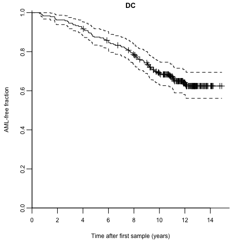

```r
torontoSurv <- Surv(torontoData$fu_years, torontoData$Diagnosis=="AML")
plot(survfit(torontoSurv~ 1), col= "black", main = "DC", xlab='Time after first sample (years)', ylab='AML-free fraction', bty='L', yaxs='i', ylim=c(0,1.01), mark.time = T)
```

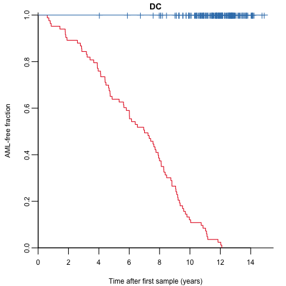

```r
plot(survfit(torontoSurv ~ torontoData$Diagnosis), xlab='Time after first sample (years)', main = "DC", ylab='AML-free fraction', bty='L', yaxs='i', ylim=c(0,1.01), mark.time = T, col = set1[1:2])
```

## 11.1 Validation cohort

```r
f = "data/VC_vaf_matrix_262ctrl_37aml_nodates.csv"
sangerData <- read.csv(f)
dim(sangerData)
```

```
## [1] 459  43
```

```r
sangerData <- sangerData[rowSums(sangerData[, colnames(sangerData) %in% gene_vars])>0 | sangerData$Diagnosis == "AML", ]
dim(sangerData)
```

```
## [1] 173  43
```

```r
length(unique(sangerData$Individual))
```

```
## [1] 128
```

```r
sangerData$hcdate <- as.Date(sangerData$hcdate)
sangerData$dodx <- as.Date(sangerData$dodx)

sangerPatients <- sub("[a-z]+$","", sangerData$Sample)
o <- order(sangerPatients, as.numeric(sangerData$hcdate))

sangerData <- sangerData[o,]
sangerPatients <- sangerPatients[o]

clinical_vars <- c("systol", "diastol", "bmi", "cholestl", "triglyc", "hdl", "ldl", "lym", "mcv", "rdw", "wbc", "plt", "hgb")
sangerX <- sangerData[, colnames(sangerData) %in% c(gene_vars, "age","gender",clinical_vars)]
sangerX <- as.data.frame(sangerX)

sangerX <- sangerX[,colSums(sangerX != 0,na.rm=TRUE)>=thr]
sangerGroups <- factor(grepl("^[a-z]", colnames(sangerX))*2, levels=0:2, labels=c("Genes", "Demographics", "Blood"))
sangerGroups[names(sangerX) %in% c("age","gender")] <- "Demographics"
table(sangerGroups)
```

```
## sangerGroups
##        Genes Demographics        Blood
##           15            2           13
```

```r
colnames(sangerX)
```

```
##  [1] "ASXL1"    "CBL"      "DNMT3A"   "JAK2"     "KMT2C"    "KMT2D"    "KRAS"     "NF1"      "NRAS"     "RAD21"
## [11] "SF3B1"    "SRSF2"    "TET2"     "TP53"     "U2AF1"    "age"      "gender"   "systol"   "diastol"  "bmi"
## [21] "cholestl" "triglyc"  "hdl"      "ldl"      "lym"      "mcv"      "rdw"      "wbc"      "plt"      "hgb"
```

```r
sangerGroups
```

```
##  [1] Genes        Genes        Genes        Genes        Genes        Genes        Genes        Genes
##  [9] Genes        Genes        Genes        Genes        Genes        Genes        Genes        Demographics
## [17] Demographics Blood        Blood        Blood        Blood        Blood        Blood        Blood
## [25] Blood        Blood        Blood        Blood        Blood        Blood
## Levels: Genes Demographics Blood
```

```r
g <- sangerGroups=="Genes"
sangerX[g] <- sangerX[g] * 10
names(sangerX)[g] <- paste(names(sangerX[g]),"0.1", sep="_")
y <- StandardizeMagnitude(sangerX[!g])
sangerX <- cbind(sangerX[g],y)

poorMansImpute <- function(x) {x[is.na(x)] <- mean(x, na.rm=TRUE); return(x)}
sangerX <- as.data.frame(sapply(sangerX, poorMansImpute))

foo <- split(sangerData[,c("Diagnosis","hcdate","dodx")], sangerPatients)

bar <- do.call("rbind",lapply(foo, function(x){
  y <- x
  n <- nrow(y)
  y[-n,"Diagnosis"] <- "Control"
  start <- as.numeric(y$hcdate - y$hcdate[1])/365.25
  end <- c(as.numeric(y$hcdate - y$hcdate[1])[-1]/365.25, as.numeric(y$dodx[n] - y$hcdate[1])/365.25)
  return(data.frame(Diagnosis=y[,"Diagnosis"], start=start, end=end))
}))

bar[1:10, ]
```

|  | Diagnosis | start | end |
| --- | --- | --- | --- |
| PD29762 | AML | 0.000000 | 9.754962 |
| PD29764 | AML | 0.000000 | 10.360027 |
| PD29792 | AML | 0.000000 | 14.108145 |
| PD29810 | Control | 0.000000 | 18.573580 |
| PD29836.1 | Control | 0.000000 | 2.414784 |
| PD29836.2 | AML | 2.414784 | 10.023272 |
| PD29851.1 | Control | 0.000000 | 4.599589 |
| PD29851.2 | AML | 4.599589 | 12.205339 |
| PD29856.1 | Control | 0.000000 | 4.331280 |
| PD29856.2 | AML | 4.331280 | 17.828884 |

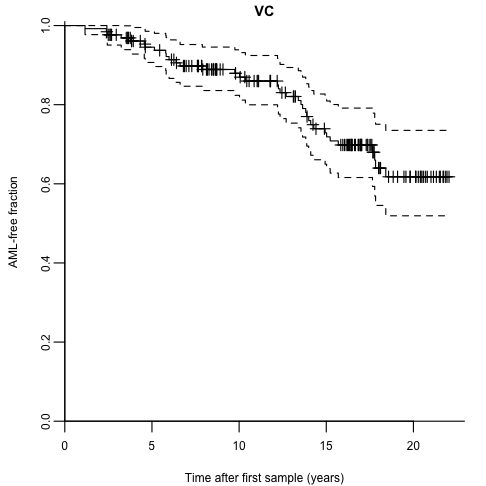

```r
sangerPatientsSplit <- unlist(sapply(names(foo), function(n) rep(n, nrow(foo[[n]]))))

sangerSurv <- Surv(time = bar$start, time2 = bar$end, event = bar$Diagnosis!="Control", origin = 0)

plot(survfit(sangerSurv~ 1), col= "black", main = "VC", xlab='Time after first sample (years)', ylab='AML-free fraction', bty='L', yaxs='i', ylim=c(0,1.01), mark.time = T) #mark = 1
```

## 11.2 Expected AML incidence

Validation cohort

```r
w <- c(which(sangerSurv[,1]==0)[-1]-1, nrow(sangerSurv))
sangerSurv2 <- Surv(sangerSurv[w,2], sangerSurv[w,3]) ## Unique individuals

expected_rate_sanger_cr <- mean(aml_inc_cr(sangerX[w,"gender"],sangerX[w,"age_10"]*10, sangerX[w,"age_10"]*10+ pmax(1,sangerSurv2[,1]))[!sangerSurv2[,2]])

n_total_sanger <- sum(sangerSurv2[,2])/expected_rate_sanger_cr
n_total_sanger
```

```
## [1] 14208.3
```

Discovery cohort

```r
expected_rate_toronto_cr <- mean(aml_inc_cr(torontoX[,"gender"],torontoX[,"age_10"]*10, torontoX[,"age_10"]*10+ pmax(1,torontoSurv[,1]))[!torontoSurv[,2]])

n_total_toronto <- sum(torontoSurv[,2])/expected_rate_toronto_cr
n_total_toronto
```

```
## [1] 55688.66
```

## 11.3 Combined data

Survival

```r
allSurv <- rbind(sangerSurv, Surv(rep(0, nrow(torontoSurv)), torontoSurv[,1], torontoSurv[,2]))
allSurv <- Surv(allSurv[,1], allSurv[,2], allSurv[,3])
```

Data matrix

```r
cohort <- c(rep("Sanger", nrow(sangerX)), rep("Toronto", nrow(torontoX)))
i <- c(sort(setdiff(gene_vars,"CALR")),"age","gender")
allX <- rbind(superSet(sangerData,i,fill=0), superSet(torontoData,i,fill=0))
allX <- allX[,colSums(allX>0)>=thr]
allX <- cbind(allX, cohort=cohort=="Sanger") + 0
allGroups <- factor(grepl("^[A-Z]",colnames(allX))+0, levels=1:0, labels=c("Genes","Demographics"))

g <- allGroups=="Genes"
allX <- cbind(10*allX[,g], StandardizeMagnitude(allX[,!g]))
colnames(allX)[g] <- paste(colnames(allX)[g],"0.1",sep="_")
control <- c(sangerData$Diagnosis=="Control", torontoData$Diagnosis=="Control")
```

Weights

```r
weights <- rep(1, nrow(allX))
weights[cohort=="Sanger" & control] <- n_total_sanger/sum(cohort=="Sanger" & control & allSurv[,1]==0)
weights[cohort=="Toronto" & control] <- n_total_toronto/sum(cohort=="Toronto" & control)

n_total <- n_total_sanger + n_total_toronto
n_total
```

```
## [1] 69896.97
```

## 11.4 Coxph model fits

```r
sigma0 <- 0.1
nu <- 1
which.mu <- "Genes"
```

### 11.4.1 DC

#### 11.4.1.1 Raw

```r
fitToronto <- CoxRFX(torontoX, torontoSurv, groups=torontoGroups, which.mu=which.mu, nu=nu, sigma0=sigma0)
waldToronto <- WaldTest(fitToronto)
```

```
##                   group    coef   coef-mu     sd      z df  p.value sig
## ASXL1_0.1         Genes  0.4801  0.050389 0.1108  4.335  1 1.46e-05 ***
## CALR_0.1          Genes  0.4076 -0.022055 0.0700  5.824  1 5.76e-09 ***
## CBL_0.1           Genes  0.3119 -0.117817 0.1151  2.710  1 6.72e-03  **
## DNMT3A_0.1        Genes  0.3010 -0.128687 0.1054  2.857  1 4.28e-03  **
## IDH1_0.1          Genes  0.4535  0.023828 0.1092  4.152  1 3.29e-05 ***
## IDH2_0.1          Genes  0.3789 -0.050806 0.1052  3.602  1 3.15e-04 ***
## JAK2_0.1          Genes  0.4956  0.065922 0.1136  4.364  1 1.28e-05 ***
## KDM6A_0.1         Genes  0.4288 -0.000932 0.0594  7.214  1 5.45e-13 ***
## KMT2C_0.1         Genes  0.4450  0.015284 0.0619  7.194  1 6.28e-13 ***
## KRAS_0.1          Genes  0.4257 -0.004039 0.0595  7.156  1 8.31e-13 ***
## NF1_0.1           Genes  0.4272 -0.002451 0.0595  7.183  1 6.80e-13 ***
## PHF6_0.1          Genes  0.4321  0.002404 0.0598  7.230  1 4.83e-13 ***
## PTPN11_0.1        Genes  0.4414  0.011735 0.0596  7.407  1 1.29e-13 ***
## RUNX1_0.1         Genes  0.2761 -0.153642 0.0890  3.102  1 1.92e-03  **
## SF3B1_0.1         Genes  0.5346  0.104912 0.0892  5.993  1 2.06e-09 ***
## SRSF2_0.1         Genes  0.3772 -0.052539 0.0883  4.274  1 1.92e-05 ***
## TET2_0.1          Genes  0.4247 -0.005040 0.1174  3.617  1 2.98e-04 ***
## TP53_0.1          Genes  0.5441  0.114421 0.0665  8.181  1 2.81e-16 ***
## U2AF1_0.1         Genes  0.5788  0.149112 0.0722  8.015  1 1.10e-15 ***
## age_10     Demographics -0.3093 -0.309301 0.1116 -2.771  1 5.59e-03  **
## gender     Demographics -0.0253 -0.025329 0.1385 -0.183  1 8.55e-01
```

```r
survConcordance(fitToronto$surv ~ fitToronto$linear.predictors, weights = weights[cohort=="Toronto"])
```

```
## Call:
## survConcordance(formula = fitToronto$surv ~ fitToronto$linear.predictors,
##     weights = weights[cohort == "Toronto"])
##
##   n= 240
## Concordance= 0.7539084 se= 0.03193557
## concordant discordant  tied.risk  tied.time   std(c-d)
##  3255935.4  1062805.9        0.0        1.0   275842.9
```

#### 11.4.1.2 Adjusted

```r
fitWeightedToronto <- CoxRFX(torontoX, torontoSurv, torontoGroups, which.mu=which.mu, sigma0=sigma0, nu=nu, weights=weights[cohort=="Toronto"])
waldWeightedToronto <- WaldTest(fitWeightedToronto)
```

```
##                   group    coef coef-mu    sd       z df  p.value sig
## ASXL1_0.1         Genes  1.9719  0.1365 0.150 13.1816  1 1.12e-39 ***
## CALR_0.1          Genes -0.0794 -1.9147 1.174 -0.0676  1 9.46e-01
## CBL_0.1           Genes  0.0165 -1.8188 0.426  0.0388  1 9.69e-01
## DNMT3A_0.1        Genes  0.3722 -1.4631 0.153  2.4301  1 1.51e-02   *
## IDH1_0.1          Genes  2.3375  0.5022 0.350  6.6815  1 2.36e-11 ***
## IDH2_0.1          Genes  0.5915 -1.2438 0.240  2.4621  1 1.38e-02   *
## JAK2_0.1          Genes  1.7762 -0.0592 0.193  9.2213  1 2.94e-20 ***
## KDM6A_0.1         Genes  1.6689 -0.1664 0.362  4.6081  1 4.06e-06 ***
## KMT2C_0.1         Genes -1.2330 -3.0683 1.191 -1.0356  1 3.00e-01
## KRAS_0.1          Genes  0.9875 -0.8478 0.555  1.7785  1 7.53e-02   .
## NF1_0.1           Genes  1.3623 -0.4730 0.501  2.7193  1 6.54e-03  **
## PHF6_0.1          Genes  2.6990  0.8636 0.255 10.5887  1 3.36e-26 ***
## PTPN11_0.1        Genes  3.6339  1.7986 0.723  5.0228  1 5.09e-07 ***
## RUNX1_0.1         Genes  0.6233 -1.2120 0.136  4.5906  1 4.42e-06 ***
## SF3B1_0.1         Genes  3.1088  1.2735 0.305 10.1981  1 2.02e-24 ***
## SRSF2_0.1         Genes  1.4956 -0.3397 0.172  8.6791  1 3.99e-18 ***
## TET2_0.1          Genes  0.5772 -1.2581 0.232  2.4920  1 1.27e-02   *
## TP53_0.1          Genes  8.9422  7.1069 0.823 10.8665  1 1.66e-27 ***
## U2AF1_0.1         Genes  4.0190  2.1836 0.384 10.4738  1 1.14e-25 ***
## age_10     Demographics -0.5274 -0.5274 0.135 -3.9171  1 8.96e-05 ***
## gender     Demographics  0.0323  0.0323 0.175  0.1842  1 8.54e-01
```

```r
survConcordance(fitWeightedToronto$surv ~ fitWeightedToronto$linear.predictors, weights=weights[cohort=="Toronto"])
```

```
## Call:
## survConcordance(formula = fitWeightedToronto$surv ~ fitWeightedToronto$linear.predictors,
##     weights = weights[cohort == "Toronto"])
##
##   n= 240
## Concordance= 0.7701663 se= 0.03193557
## concordant discordant  tied.risk  tied.time   std(c-d)
##  3326148.9   992592.4        0.0        1.0   275842.9
```

```r
#Uno's estimator of cumulative/dynamic AUC
a <- AUC.uno(torontoSurv, torontoSurv, fitWeightedToronto$linear.predictors, times= seq(0,12, 0.1))
round(a$iauc, digits = 3)
```

```
## [1] 0.756
```

### 11.4.2 Validation cohort

#### 11.4.2.1 Raw

```r
fitSanger <- CoxRFX(sangerX, sangerSurv, groups=sangerGroups, which.mu=which.mu, nu=nu, sigma0=sigma0)
waldSanger <- WaldTest(fitSanger)
```

```
##                    group     coef   coef-mu      sd       z df  p.value sig
## ASXL1_0.1          Genes  0.41389  1.04e-01 0.13253  3.1229  1 1.79e-03  **
## CBL_0.1            Genes  0.27978 -3.01e-02 0.10678  2.6202  1 8.79e-03  **
## DNMT3A_0.1         Genes  0.15476 -1.55e-01 0.12703  1.2183  1 2.23e-01
## JAK2_0.1           Genes  0.33012  2.02e-02 0.10874  3.0359  1 2.40e-03  **
## KMT2C_0.1          Genes  0.30175 -8.17e-03 0.09722  3.1037  1 1.91e-03  **
## KMT2D_0.1          Genes  0.14350 -1.66e-01 0.15722  0.9127  1 3.61e-01
## KRAS_0.1           Genes  0.30998  5.67e-05 0.09168  3.3811  1 7.22e-04 ***
## NF1_0.1            Genes  0.29225 -1.77e-02 0.09499  3.0768  1 2.09e-03  **
## NRAS_0.1           Genes  0.30685 -3.07e-03 0.09158  3.3507  1 8.06e-04 ***
## RAD21_0.1          Genes  0.29301 -1.69e-02 0.09373  3.1261  1 1.77e-03  **
## SF3B1_0.1          Genes  0.29894 -1.10e-02 0.09393  3.1825  1 1.46e-03  **
## SRSF2_0.1          Genes  0.40493  9.50e-02 0.13441  3.0125  1 2.59e-03  **
## TET2_0.1           Genes  0.37910  6.92e-02 0.11275  3.3624  1 7.73e-04 ***
## TP53_0.1           Genes  0.36746  5.75e-02 0.09308  3.9479  1 7.88e-05 ***
## U2AF1_0.1          Genes  0.37254  6.26e-02 0.09357  3.9813  1 6.85e-05 ***
## age_10      Demographics -0.01773 -1.77e-02 0.11451 -0.1548  1 8.77e-01
## gender      Demographics -0.03369 -3.37e-02 0.10501 -0.3208  1 7.48e-01
## systol_100         Blood  0.00145  1.45e-03 0.03839  0.0377  1 9.70e-01
## diastol_100        Blood  0.00773  7.73e-03 0.02329  0.3321  1 7.40e-01
## bmi_10             Blood  0.06828  6.83e-02 0.07091  0.9628  1 3.36e-01
## cholestl_10        Blood  0.01797  1.80e-02 0.01274  1.4109  1 1.58e-01
## triglyc            Blood  0.00471  4.71e-03 0.09569  0.0492  1 9.61e-01
## hdl                Blood -0.00891 -8.91e-03 0.07257 -0.1227  1 9.02e-01
## ldl                Blood  0.16056  1.61e-01 0.09725  1.6510  1 9.87e-02   .
## lym                Blood -0.02015 -2.01e-02 0.08835 -0.2280  1 8.20e-01
## mcv_100            Blood -0.00369 -3.69e-03 0.00786 -0.4694  1 6.39e-01
## rdw_10             Blood  0.05420  5.42e-02 0.02080  2.6056  1 9.17e-03  **
## wbc_10             Blood  0.00379  3.79e-03 0.03521  0.1077  1 9.14e-01
## plt_100            Blood  0.03410  3.41e-02 0.09166  0.3720  1 7.10e-01
## hgb_10             Blood  0.03314  3.31e-02 0.02245  1.4763  1 1.40e-01
```

```r
survConcordance(sangerSurv ~ fitSanger$linear.predictors)
```

```
## Call:
## survConcordance(formula = sangerSurv ~ fitSanger$linear.predictors)
##
##   n= 173
## Concordance= 0.6611972 se= 0.05025086
## concordant discordant  tied.risk  tied.time   std(c-d)
##  2176.0000  1115.0000     0.0000     0.0000   330.7512
```

#### 11.4.2.2 Adjusted

```r
fitWeightedSanger <- CoxRFX(sangerX, sangerSurv, sangerGroups, which.mu=which.mu, sigma0=sigma0, nu=nu, weights=weights[cohort=="Sanger"])
waldWeightedSanger <- WaldTest(fitWeightedSanger)
```

```
##                    group      coef   coef-mu      sd        z df  p.value sig
## ASXL1_0.1          Genes  2.580959  1.414558 0.47618  5.42008  1 5.96e-08 ***
## CBL_0.1            Genes -0.660213 -1.826614 1.39628 -0.47284  1 6.36e-01
## DNMT3A_0.1         Genes  0.223151 -0.943251 0.24504  0.91066  1 3.62e-01
## JAK2_0.1           Genes  0.705927 -0.460474 1.04486  0.67562  1 4.99e-01
## KMT2C_0.1          Genes -0.385529 -1.551931 1.44435 -0.26692  1 7.90e-01
## KMT2D_0.1          Genes -0.627231 -1.793633 1.03607 -0.60539  1 5.45e-01
## KRAS_0.1           Genes  1.299133  0.132731 0.78999  1.64450  1 1.00e-01
## NF1_0.1            Genes -0.815764 -1.982166 1.46470 -0.55695  1 5.78e-01
## NRAS_0.1           Genes  0.728314 -0.438088 0.64251  1.13355  1 2.57e-01
## RAD21_0.1          Genes -0.678392 -1.844793 1.44210 -0.47042  1 6.38e-01
## SF3B1_0.1          Genes  0.072745 -1.093657 1.47708  0.04925  1 9.61e-01
## SRSF2_0.1          Genes  1.726024  0.559622 0.23912  7.21826  1 5.27e-13 ***
## TET2_0.1           Genes  1.101278 -0.065124 0.15079  7.30320  1 2.81e-13 ***
## TP53_0.1           Genes  4.694801  3.528400 1.13074  4.15198  1 3.30e-05 ***
## U2AF1_0.1          Genes  7.530821  6.364419 1.06931  7.04270  1 1.89e-12 ***
## age_10      Demographics -0.190256 -0.190256 0.13151 -1.44666  1 1.48e-01
## gender      Demographics -0.029742 -0.029742 0.12174 -0.24430  1 8.07e-01
## systol_100         Blood -0.032537 -0.032537 0.04764 -0.68293  1 4.95e-01
## diastol_100        Blood  0.000105  0.000105 0.02958  0.00356  1 9.97e-01
## bmi_10             Blood  0.098774  0.098774 0.08970  1.10111  1 2.71e-01
## cholestl_10        Blood  0.024226  0.024226 0.01553  1.55989  1 1.19e-01
## triglyc            Blood  0.051097  0.051097 0.11392  0.44854  1 6.54e-01
## hdl                Blood -0.082426 -0.082426 0.09326 -0.88380  1 3.77e-01
## ldl                Blood  0.248075  0.248075 0.11127  2.22950  1 2.58e-02   *
## lym                Blood -0.054414 -0.054414 0.10621 -0.51234  1 6.08e-01
## mcv_100            Blood -0.010783 -0.010783 0.00915 -1.17903  1 2.38e-01
## rdw_10             Blood  0.095279  0.095279 0.01797  5.30078  1 1.15e-07 ***
## wbc_10             Blood  0.011314  0.011314 0.04898  0.23099  1 8.17e-01
## plt_100            Blood  0.057755  0.057755 0.11248  0.51347  1 6.08e-01
## hgb_10             Blood  0.016212  0.016212 0.02615  0.62004  1 5.35e-01
```

```r
waldWeightedSanger$p.adj <- p.adjust(p = waldWeightedSanger$p.value, method = "bonferroni")
#View(waldWeightedSanger)

survConcordance(sangerSurv ~ fitWeightedSanger$linear.predictors, weights=weights[cohort=="Sanger"])
```

```
## Call:
## survConcordance(formula = sangerSurv ~ fitWeightedSanger$linear.predictors,
##     weights = weights[cohort == "Sanger"])
##
##   n= 173
## Concordance= 0.7231124 se= 0.0489519
## concordant discordant  tied.risk  tied.time   std(c-d)
##  296852.77  113668.16       0.00       0.00   40191.56
```

```r
#Uno's estimator of cumulative/dynamic AUC
w <- c(which(sangerSurv[,1]==0)[-1]-1, nrow(sangerSurv))
s <- Surv(sangerSurv[w,2], sangerSurv[w,3])
a <- AUC.uno(s, s, fitWeightedSanger$linear.predictors[w], times= c(0, 22, 0.1))
round(a$iauc, digits = 3)
```

```
## [1] 0.403
```

# 12 CoxPH model excluding all samples without ARCH-PD

## 12.1 Discovery cohort

Data

```r
f = "data/DC_vaf_matrix_414ctrl_91aml.csv"
torontoData <- read.csv(f)

gene_vars <- c("CALR", "NRAS", "DNMT3A", "SF3B1", "IDH1", "KIT", "TET2", "RAD21", "JAK2", "CBL", "KRAS", "PTPN11", "IDH2", "TP53", "NF1", "SRSF2", "CEBPA", "ASXL1", "RUNX1", "U2AF1", "BCOR", "KDM6A", "PHF6", "KMT2C", "KMT2D")

table(torontoData$Diagnosis)
```

```
##
##     AML Control
##      91     414
```

```r
torontoData$gender <- ifelse(torontoData$Sex == "male", 1,
                             ifelse(torontoData$Sex == "female", 0, torontoData$Sex))
dim(torontoData)
```

```
## [1] 505  29
```

```r
torontoData <- torontoData[rowSums(torontoData[, colnames(torontoData) %in% gene_vars])>0, ]
dim(torontoData)
```

```
## [1] 221  29
```

```r
table(torontoData$gender)
```

```
##
##   0   1
## 126  95
```

```r
torontoData$gender <- as.numeric(torontoData$gender)
colnames(torontoData)
```

```
##  [1] "Sample"     "ASXL1"      "BCOR"       "CALR"       "CBL"        "DNMT3A"     "IDH1"       "IDH2"
##  [9] "JAK2"       "KDM6A"      "KIT"        "KMT2C"      "KRAS"       "NF1"        "NRAS"       "PHF6"
## [17] "PTPN11"     "RUNX1"      "SF3B1"      "SRSF2"      "TET2"       "TP53"       "U2AF1"      "Diagnosis"
## [25] "fu_years"   "age"        "Sex"        "no_drivers" "gender"
```

Manually standardize magnitudes

```r
torontoData <- torontoData[!duplicated(torontoData),]

torontoX <- torontoData[, colnames(torontoData) %in% c(gene_vars, "age", "gender")]

torontoX <- as.data.frame(torontoX)
thr <- 2
torontoX <- torontoX[,colSums(torontoX != 0)>=thr]

torontoGroups <- factor(names(torontoX) %in% c("age","gender")+1, level=1:2, labels=c("Genes","Demographics"))
colnames(torontoX)
```

```
##  [1] "ASXL1"  "CALR"   "CBL"    "DNMT3A" "IDH1"   "IDH2"   "JAK2"   "KDM6A"  "KMT2C"  "KRAS"   "NF1"    "PHF6"
## [13] "PTPN11" "RUNX1"  "SF3B1"  "SRSF2"  "TET2"   "TP53"   "U2AF1"  "age"    "gender"
```

```r
torontoGroups
```

```
##  [1] Genes        Genes        Genes        Genes        Genes        Genes        Genes        Genes
##  [9] Genes        Genes        Genes        Genes        Genes        Genes        Genes        Genes
## [17] Genes        Genes        Genes        Demographics Demographics
## Levels: Genes Demographics
```

Manually standardize age and mutation VAFs

```r
torontoX$age <- torontoX$age/10
names(torontoX)[which(names(torontoX)=="age")] <- "age_10"
g <- torontoGroups == "Genes"
torontoX[,g] <- torontoX[,g]*10
names(torontoX)[g] <- paste(names(torontoX)[g], "0.1",sep="_")
colnames(torontoX)
```

```
##  [1] "ASXL1_0.1"  "CALR_0.1"   "CBL_0.1"    "DNMT3A_0.1" "IDH1_0.1"   "IDH2_0.1"   "JAK2_0.1"   "KDM6A_0.1"
##  [9] "KMT2C_0.1"  "KRAS_0.1"   "NF1_0.1"    "PHF6_0.1"   "PTPN11_0.1" "RUNX1_0.1"  "SF3B1_0.1"  "SRSF2_0.1"
## [17] "TET2_0.1"   "TP53_0.1"   "U2AF1_0.1"  "age_10"     "gender"
```

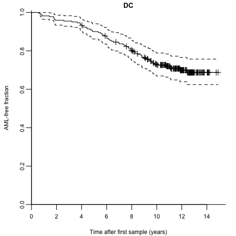

```r
torontoSurv <- Surv(torontoData$fu_years, torontoData$Diagnosis=="AML")
plot(survfit(torontoSurv~ 1), col= "black", main = "DC", xlab='Time after first sample (years)', ylab='AML-free fraction', bty='L', yaxs='i', ylim=c(0,1.01), mark.time = T)
```

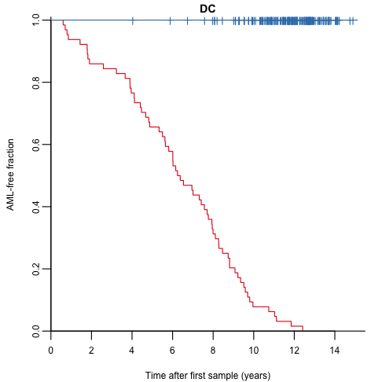

```r
plot(survfit(torontoSurv ~ torontoData$Diagnosis), xlab='Time after first sample (years)', main = "DC", ylab='AML-free fraction', bty='L', yaxs='i', ylim=c(0,1.01), mark.time = T, col = set1[1:2])
```

## 12.2 Validation cohort

```r
f = "data/VC_vaf_matrix_no_duplicates_262ctrl_29aml_nodates.csv"
sangerData <- read.csv(f)
dim(sangerData)
```

```
## [1] 445  43
```

```r
sangerData <- sangerData[rowSums(sangerData[, colnames(sangerData) %in% gene_vars])>0, ]
dim(sangerData)
```

```
## [1] 149  43
```

```r
sangerData$hcdate <- as.Date(sangerData$hcdate)
sangerData$dodx <- as.Date(sangerData$dodx)

sangerPatients <- sub("[a-z]+$","", sangerData$Sample)
o <- order(sangerPatients, as.numeric(sangerData$hcdate))

sangerData <- sangerData[o,]
sangerPatients <- sangerPatients[o]

clinical_vars <- c("systol", "diastol", "bmi", "cholestl", "triglyc", "hdl", "ldl", "lym", "mcv", "rdw", "wbc", "plt", "hgb")
sangerX <- sangerData[, colnames(sangerData) %in% c(gene_vars, "age","gender",clinical_vars)]
sangerX <- as.data.frame(sangerX)

sangerX <- sangerX[,colSums(sangerX != 0,na.rm=TRUE)>=thr]
sangerGroups <- factor(grepl("^[a-z]", colnames(sangerX))*2, levels=0:2, labels=c("Genes", "Demographics", "Blood"))
sangerGroups[names(sangerX) %in% c("age","gender")] <- "Demographics"
table(sangerGroups)
```

```
## sangerGroups
##        Genes Demographics        Blood
##           15            2           13
```

```r
colnames(sangerX)
```

```
##  [1] "ASXL1"    "CBL"      "DNMT3A"   "JAK2"     "KMT2C"    "KMT2D"    "KRAS"     "NF1"      "NRAS"     "RAD21"
## [11] "SF3B1"    "SRSF2"    "TET2"     "TP53"     "U2AF1"    "age"      "gender"   "systol"   "diastol"  "bmi"
## [21] "cholestl" "triglyc"  "hdl"      "ldl"      "lym"      "mcv"      "rdw"      "wbc"      "plt"      "hgb"
```

```r
sangerGroups
```

```
##  [1] Genes        Genes        Genes        Genes        Genes        Genes        Genes        Genes
##  [9] Genes        Genes        Genes        Genes        Genes        Genes        Genes        Demographics
## [17] Demographics Blood        Blood        Blood        Blood        Blood        Blood        Blood
## [25] Blood        Blood        Blood        Blood        Blood        Blood
## Levels: Genes Demographics Blood
```

```r
g <- sangerGroups=="Genes"
sangerX[g] <- sangerX[g] * 10
names(sangerX)[g] <- paste(names(sangerX[g]),"0.1", sep="_")
y <- StandardizeMagnitude(sangerX[!g])
sangerX <- cbind(sangerX[g],y)

poorMansImpute <- function(x) {x[is.na(x)] <- mean(x, na.rm=TRUE); return(x)}
sangerX <- as.data.frame(sapply(sangerX, poorMansImpute))

foo <- split(sangerData[,c("Diagnosis","hcdate","dodx")], sangerPatients)

bar <- do.call("rbind",lapply(foo, function(x){
  y <- x
  n <- nrow(y)
  y[-n,"Diagnosis"] <- "Control"
  start <- as.numeric(y$hcdate - y$hcdate[1])/365.25
  end <- c(as.numeric(y$hcdate - y$hcdate[1])[-1]/365.25, as.numeric(y$dodx[n] - y$hcdate[1])/365.25)
  return(data.frame(Diagnosis=y[,"Diagnosis"], start=start, end=end))
}))

bar[1:10, ]
```

|  | Diagnosis | start | end |
| --- | --- | --- | --- |
| PD29762 | AML | 0.000000 | 9.754962 |
| PD29764 | AML | 0.000000 | 10.360027 |
| PD29792 | AML | 0.000000 | 14.108145 |
| PD29810 | Control | 0.000000 | 18.573580 |
| PD29836.1 | Control | 0.000000 | 2.414784 |
| PD29836.2 | AML | 2.414784 | 10.023272 |
| PD29856 | AML | 0.000000 | 17.828884 |
| PD29896 | AML | 0.000000 | 6.387406 |
| PD29918.1 | Control | 0.000000 | 5.442847 |
| PD29918.2 | AML | 5.442847 | 13.396304 |

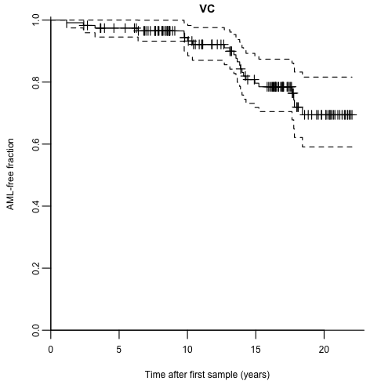

```r
sangerPatientsSplit <- unlist(sapply(names(foo), function(n) rep(n, nrow(foo[[n]]))))

sangerSurv <- Surv(time = bar$start, time2 = bar$end, event = bar$Diagnosis!="Control", origin = 0)

plot(survfit(sangerSurv~ 1), col= "black", main = "VC", xlab='Time after first sample (years)', ylab='AML-free fraction', bty='L', yaxs='i', ylim=c(0,1.01), mark.time = T) #mark = 1
```

## 12.3 Expected AML incidence

Validation cohort

```r
w <- c(which(sangerSurv[,1]==0)[-1]-1, nrow(sangerSurv))
sangerSurv2 <- Surv(sangerSurv[w,2], sangerSurv[w,3])

expected_rate_sanger_cr <- mean(aml_inc_cr(sangerX[w,"gender"],sangerX[w,"age_10"]*10, sangerX[w,"age_10"]*10+ pmax(1,sangerSurv2[,1]))[!sangerSurv2[,2]])

n_total_sanger <- sum(sangerSurv2[,2])/expected_rate_sanger_cr
n_total_sanger
```

```
## [1] 9216.197
```

Discovery cohort

```r
expected_rate_toronto_cr <- mean(aml_inc_cr(torontoX[,"gender"],torontoX[,"age_10"]*10, torontoX[,"age_10"]*10+ pmax(1,torontoSurv[,1]))[!torontoSurv[,2]])

n_total_toronto <- sum(torontoSurv[,2])/expected_rate_toronto_cr
n_total_toronto
```

```
## [1] 42940.66
```

## 12.4 Combined data

Survival

```r
allSurv <- rbind(sangerSurv, Surv(rep(0, nrow(torontoSurv)), torontoSurv[,1], torontoSurv[,2]))
allSurv <- Surv(allSurv[,1], allSurv[,2], allSurv[,3])
```

Data matrix

```r
cohort <- c(rep("Sanger", nrow(sangerX)), rep("Toronto", nrow(torontoX)))
i <- c(sort(setdiff(gene_vars,"CALR")),"age","gender")
allX <- rbind(superSet(sangerData,i,fill=0), superSet(torontoData,i,fill=0))
allX <- allX[,colSums(allX>0)>=thr]
allX <- cbind(allX, cohort=cohort=="Sanger") + 0
allGroups <- factor(grepl("^[A-Z]",colnames(allX))+0, levels=1:0, labels=c("Genes","Demographics"))

g <- allGroups=="Genes"
allX <- cbind(10*allX[,g], StandardizeMagnitude(allX[,!g]))
colnames(allX)[g] <- paste(colnames(allX)[g],"0.1",sep="_")
control <- c(sangerData$Diagnosis=="Control", torontoData$Diagnosis=="Control")
```

Weights

```r
weights <- rep(1, nrow(allX))
weights[cohort=="Sanger" & control] <- n_total_sanger/sum(cohort=="Sanger" & control & allSurv[,1]==0)
weights[cohort=="Toronto" & control] <- n_total_toronto/sum(cohort=="Toronto" & control)

n_total <- n_total_sanger + n_total_toronto
n_total
```

```
## [1] 52156.85
```

## 12.5 Coxph model fits

```r
sigma0 <- 0.1
nu <- 1
which.mu <- "Genes"
```

### 12.5.1 Toronto

#### 12.5.1.1 Raw

```r
fitToronto <- CoxRFX(torontoX, torontoSurv, groups=torontoGroups, which.mu=which.mu, nu=nu, sigma0=sigma0)
waldToronto <- WaldTest(fitToronto)
```

```
##                   group    coef   coef-mu     sd      z df  p.value sig
## ASXL1_0.1         Genes  0.5750  0.032700 0.1158  4.964  1 6.91e-07 ***
## CALR_0.1          Genes  0.5200 -0.022339 0.0744  6.990  1 2.74e-12 ***
## CBL_0.1           Genes  0.4268 -0.115522 0.1231  3.469  1 5.23e-04 ***
## DNMT3A_0.1        Genes  0.4724 -0.069936 0.1062  4.448  1 8.66e-06 ***
## IDH1_0.1          Genes  0.5730  0.030722 0.1188  4.822  1 1.42e-06 ***
## IDH2_0.1          Genes  0.4711 -0.071177 0.1126  4.184  1 2.86e-05 ***
## JAK2_0.1          Genes  0.6084  0.066072 0.1214  5.011  1 5.43e-07 ***
## KDM6A_0.1         Genes  0.5420 -0.000284 0.0628  8.629  1 6.17e-18 ***
## KMT2C_0.1         Genes  0.5603  0.017953 0.0656  8.545  1 1.29e-17 ***
## KRAS_0.1          Genes  0.5394 -0.002952 0.0628  8.583  1 9.20e-18 ***
## NF1_0.1           Genes  0.5404 -0.001954 0.0628  8.599  1 8.07e-18 ***
## PHF6_0.1          Genes  0.5469  0.004542 0.0632  8.655  1 4.91e-18 ***
## PTPN11_0.1        Genes  0.5556  0.013243 0.0631  8.810  1 1.25e-18 ***
## RUNX1_0.1         Genes  0.3347 -0.207621 0.0917  3.650  1 2.62e-04 ***
## SF3B1_0.1         Genes  0.6532  0.110858 0.0963  6.781  1 1.19e-11 ***
## SRSF2_0.1         Genes  0.4370 -0.105330 0.0920  4.750  1 2.03e-06 ***
## TET2_0.1          Genes  0.5053 -0.037059 0.1248  4.050  1 5.12e-05 ***
## TP53_0.1          Genes  0.7280  0.185639 0.0825  8.828  1 1.07e-18 ***
## U2AF1_0.1         Genes  0.7148  0.172443 0.0805  8.879  1 6.76e-19 ***
## age_10     Demographics -0.0236 -0.023625 0.1092 -0.216  1 8.29e-01
## gender     Demographics -0.0832 -0.083228 0.1113 -0.748  1 4.55e-01
```

```r
survConcordance(fitToronto$surv ~ fitToronto$linear.predictors)
```

```
## Call:
## survConcordance(formula = fitToronto$surv ~ fitToronto$linear.predictors)
##
##   n= 221
## Concordance= 0.7806171 se= 0.03687602
## concordant discordant  tied.risk  tied.time   std(c-d)
##  8981.0000  2524.0000     0.0000     1.0000   848.5173
```

#### 12.5.1.2 Adjusted

```r
fitWeightedToronto <- CoxRFX(torontoX, torontoSurv, torontoGroups, which.mu=which.mu, sigma0=sigma0, nu=nu, weights=weights[cohort=="Toronto"])
waldWeightedToronto <- WaldTest(fitWeightedToronto)
```

```
##                   group    coef  coef-mu    sd      z df  p.value sig
## ASXL1_0.1         Genes  1.9878  0.06756 0.150 13.267  1 3.60e-40 ***
## CALR_0.1          Genes  0.6189 -1.30126 0.758  0.817  1 4.14e-01
## CBL_0.1           Genes  0.2531 -1.66705 0.379  0.668  1 5.04e-01
## DNMT3A_0.1        Genes  0.5859 -1.33434 0.136  4.313  1 1.61e-05 ***
## IDH1_0.1          Genes  2.4124  0.49218 0.341  7.083  1 1.41e-12 ***
## IDH2_0.1          Genes  0.8067 -1.11352 0.231  3.498  1 4.70e-04 ***
## JAK2_0.1          Genes  1.9535  0.03333 0.193 10.131  1 4.01e-24 ***
## KDM6A_0.1         Genes  1.9181 -0.00209 0.163 11.792  1 4.31e-32 ***
## KMT2C_0.1         Genes  2.3735  0.45328 0.730  3.250  1 1.16e-03  **
## KRAS_0.1          Genes  1.7434 -0.17684 0.195  8.955  1 3.38e-19 ***
## NF1_0.1           Genes  1.8059 -0.11434 0.190  9.518  1 1.77e-21 ***
## PHF6_0.1          Genes  2.2276  0.30741 0.144 15.462  1 6.24e-54 ***
## PTPN11_0.1        Genes  2.5970  0.67679 0.277  9.366  1 7.52e-21 ***
## RUNX1_0.1         Genes  0.7172 -1.20303 0.137  5.235  1 1.65e-07 ***
## SF3B1_0.1         Genes  3.2528  1.33260 0.321 10.149  1 3.36e-24 ***
## SRSF2_0.1         Genes  1.4698 -0.45035 0.170  8.656  1 4.91e-18 ***
## TET2_0.1          Genes  0.5707 -1.34952 0.211  2.699  1 6.96e-03  **
## TP53_0.1          Genes  5.2413  3.32111 0.440 11.916  1 9.82e-33 ***
## U2AF1_0.1         Genes  3.9483  2.02809 0.365 10.817  1 2.87e-27 ***
## age_10     Demographics -0.0820 -0.08201 0.117 -0.700  1 4.84e-01
## gender     Demographics -0.0899 -0.08989 0.117 -0.771  1 4.41e-01
```

```r
survConcordance(fitWeightedToronto$surv ~ fitWeightedToronto$linear.predictors, weights=weights[cohort=="Toronto"])
```

```
## Call:
## survConcordance(formula = fitWeightedToronto$surv ~ fitWeightedToronto$linear.predictors,
##     weights = weights[cohort == "Toronto"])
##
##   n= 221
## Concordance= 0.8454794 se= 0.03633541
## concordant discordant  tied.risk  tied.time   std(c-d)
##  2196217.1   401382.8        0.0        1.0   188769.7
```

Uno’s estimator of cumulative/dynamic AUC

```r
a <- AUC.uno(torontoSurv, torontoSurv, fitWeightedToronto$linear.predictors, times= seq(0,12, 0.1))
round(a$iauc, digits = 3)
```

```
## [1] 0.791
```

### 12.5.2 Validation cohort

#### 12.5.2.1 Raw

```r
fitSanger <- CoxRFX(sangerX, sangerSurv, groups=sangerGroups, which.mu=which.mu, nu=nu, sigma0=sigma0)
waldSanger <- WaldTest(fitSanger)
```

```
##                    group      coef   coef-mu      sd        z df  p.value sig
## ASXL1_0.1          Genes  0.673478  0.158950 0.12882  5.22794  1 1.71e-07 ***
## CBL_0.1            Genes  0.495353 -0.019175 0.10735  4.61426  1 3.94e-06 ***
## DNMT3A_0.1         Genes  0.328415 -0.186113 0.13178  2.49210  1 1.27e-02   *
## JAK2_0.1           Genes  0.493355 -0.021173 0.11739  4.20278  1 2.64e-05 ***
## KMT2C_0.1          Genes  0.519077  0.004549 0.10042  5.16888  1 2.36e-07 ***
## KMT2D_0.1          Genes  0.341708 -0.172820 0.16670  2.04989  1 4.04e-02   *
## KRAS_0.1           Genes  0.517799  0.003272 0.09650  5.36592  1 8.05e-08 ***
## NF1_0.1            Genes  0.501902 -0.012625 0.09919  5.06022  1 4.19e-07 ***
## NRAS_0.1           Genes  0.534425  0.019897 0.09703  5.50790  1 3.63e-08 ***
## RAD21_0.1          Genes  0.503868 -0.010660 0.09793  5.14544  1 2.67e-07 ***
## SF3B1_0.1          Genes  0.507855 -0.006673 0.09801  5.18184  1 2.20e-07 ***
## SRSF2_0.1          Genes  0.529928  0.015400 0.14168  3.74021  1 1.84e-04 ***
## TET2_0.1           Genes  0.593720  0.079192 0.12273  4.83743  1 1.32e-06 ***
## TP53_0.1           Genes  0.584538  0.070010 0.09773  5.98121  1 2.21e-09 ***
## U2AF1_0.1          Genes  0.592496  0.077968 0.09770  6.06442  1 1.32e-09 ***
## age_10      Demographics  0.084731  0.084731 0.12166  0.69645  1 4.86e-01
## gender      Demographics -0.007960 -0.007960 0.10340 -0.07698  1 9.39e-01
## systol_100         Blood  0.033564  0.033564 0.03644  0.92111  1 3.57e-01
## diastol_100        Blood  0.032432  0.032432 0.02299  1.41095  1 1.58e-01
## bmi_10             Blood  0.081752  0.081752 0.06892  1.18610  1 2.36e-01
## cholestl_10        Blood  0.014082  0.014082 0.01344  1.04742  1 2.95e-01
## triglyc            Blood -0.000827 -0.000827 0.10813 -0.00765  1 9.94e-01
## hdl                Blood -0.007587 -0.007587 0.06927 -0.10952  1 9.13e-01
## ldl                Blood  0.134372  0.134372 0.11043  1.21684  1 2.24e-01
## lym                Blood  0.076500  0.076500 0.08867  0.86278  1 3.88e-01
## mcv_100            Blood -0.012801 -0.012801 0.00713 -1.79436  1 7.28e-02   .
## rdw_10             Blood  0.058557  0.058557 0.01828  3.20254  1 1.36e-03  **
## wbc_10             Blood  0.016691  0.016691 0.03908  0.42707  1 6.69e-01
## plt_100            Blood  0.095820  0.095820 0.09229  1.03821  1 2.99e-01
## hgb_10             Blood  0.006904  0.006904 0.01981  0.34856  1 7.27e-01
```

```r
survConcordance(sangerSurv ~ fitSanger$linear.predictors)
```

```
## Call:
## survConcordance(formula = sangerSurv ~ fitSanger$linear.predictors)
##
##   n= 149
## Concordance= 0.7918502 se= 0.06247796
## concordant discordant  tied.risk  tied.time   std(c-d)
##    1438.00     378.00       0.00       0.00     226.92
```

#### 12.5.2.2 Adjusted

```r
fitWeightedSanger <- CoxRFX(sangerX, sangerSurv, sangerGroups, which.mu=which.mu, sigma0=sigma0, nu=nu, weights=weights[cohort=="Sanger"])
waldWeightedSanger <- WaldTest(fitWeightedSanger)
```

```
##                    group    coef coef-mu     sd       z df  p.value sig
## ASXL1_0.1          Genes  3.2736  1.1639 0.5035  6.5016  1 7.95e-11 ***
## CBL_0.1            Genes  0.4415 -1.6682 1.4885  0.2966  1 7.67e-01
## DNMT3A_0.1         Genes  0.5963 -1.5134 0.2434  2.4497  1 1.43e-02   *
## JAK2_0.1           Genes -0.0225 -2.1322 1.0506 -0.0214  1 9.83e-01
## KMT2C_0.1          Genes  0.8233 -1.2864 1.4975  0.5498  1 5.82e-01
## KMT2D_0.1          Genes -0.1936 -2.3033 0.9186 -0.2108  1 8.33e-01
## KRAS_0.1           Genes  2.6546  0.5449 0.6402  4.1468  1 3.37e-05 ***
## NF1_0.1            Genes  0.8839 -1.2258 1.4275  0.6192  1 5.36e-01
## NRAS_0.1           Genes  4.8796  2.7699 0.6294  7.7532  1 8.96e-15 ***
## RAD21_0.1          Genes  0.8665 -1.2432 1.4103  0.6144  1 5.39e-01
## SF3B1_0.1          Genes  1.2701 -0.8396 1.4768  0.8601  1 3.90e-01
## SRSF2_0.1          Genes  1.6909 -0.4188 0.2626  6.4399  1 1.20e-10 ***
## TET2_0.1           Genes  1.3640 -0.7457 0.1595  8.5534  1 1.19e-17 ***
## TP53_0.1           Genes  5.1102  3.0005 1.0728  4.7634  1 1.90e-06 ***
## U2AF1_0.1          Genes  8.0069  5.8972 0.9739  8.2214  1 2.01e-16 ***
## age_10      Demographics -0.0522 -0.0522 0.1212 -0.4306  1 6.67e-01
## gender      Demographics -0.0216 -0.0216 0.0988 -0.2185  1 8.27e-01
## systol_100         Blood  0.0064  0.0064 0.0409  0.1566  1 8.76e-01
## diastol_100        Blood  0.0251  0.0251 0.0269  0.9320  1 3.51e-01
## bmi_10             Blood  0.0956  0.0956 0.0826  1.1574  1 2.47e-01
## cholestl_10        Blood  0.0143  0.0143 0.0155  0.9246  1 3.55e-01
## triglyc            Blood -0.0533 -0.0533 0.1279 -0.4169  1 6.77e-01
## hdl                Blood -0.0505 -0.0505 0.0839 -0.6015  1 5.48e-01
## ldl                Blood  0.2011  0.2011 0.1239  1.6229  1 1.05e-01
## lym                Blood  0.0499  0.0499 0.0996  0.5009  1 6.16e-01
## mcv_100            Blood -0.0238 -0.0238 0.0075 -3.1777  1 1.48e-03  **
## rdw_10             Blood  0.0832  0.0832 0.0142  5.8698  1 4.36e-09 ***
## wbc_10             Blood  0.0108  0.0108 0.0544  0.1988  1 8.42e-01
## plt_100            Blood  0.1509  0.1509 0.1056  1.4297  1 1.53e-01
## hgb_10             Blood -0.0224 -0.0224 0.0217 -1.0308  1 3.03e-01
```

```r
survConcordance(sangerSurv ~ fitWeightedSanger$linear.predictors, weights=weights[cohort=="Sanger"])
```

```
## Call:
## survConcordance(formula = sangerSurv ~ fitWeightedSanger$linear.predictors,
##     weights = weights[cohort == "Sanger"])
##
##   n= 149
## Concordance= 0.8671072 se= 0.06105924
## concordant discordant  tied.risk  tied.time   std(c-d)
##  135478.93   20763.49       0.00       0.00   19080.09
```

Uno’s estimator of cumulative/dynamic AUC

```r
w <- c(which(sangerSurv[,1]==0)[-1]-1, nrow(sangerSurv))
s <- Surv(sangerSurv[w,2], sangerSurv[w,3])
a <- AUC.uno(s, s, fitWeightedSanger$linear.predictors[w], times= c(0, 22, 0.1))
round(a$iauc, digits = 3)
```

```
## [1] 0.587
```

```
##  setting  value
##  version  R version 3.5.1 (2018-07-02)
##  system   x86_64, darwin17.6.0
##  ui       X11
##  language (EN)
##  collate  C
##  tz       Europe/London
##  date     2018-07-24
```

```
## Packages --------------------------------------------------------------------------------------------------------------
```

```
##  package      * version  date       source
##  abind          1.4-5    2016-07-21 CRAN (R 3.5.1)
##  assertthat     0.2.0    2017-04-11 CRAN (R 3.5.1)
##  backports      1.1.2    2017-12-13 cran (@1.1.2)
##  base         * 3.5.1    2018-07-09 local
##  bindr          0.1.1    2018-03-13 CRAN (R 3.5.1)
##  bindrcpp       0.2.2    2018-03-29 CRAN (R 3.5.1)
##  bitops         1.0-6    2013-08-17 CRAN (R 3.5.1)
##  broom          0.5.0    2018-07-17 cran (@0.5.0)
##  car            3.0-0    2018-04-02 CRAN (R 3.5.1)
##  carData        3.0-1    2018-03-28 CRAN (R 3.5.1)
##  caTools        1.17.1.1 2018-07-20 CRAN (R 3.5.1)
##  cellranger     1.1.0    2016-07-27 CRAN (R 3.5.1)
##  codetools      0.2-15   2016-10-05 CRAN (R 3.5.1)
##  compiler       3.5.1    2018-07-09 local
##  CoxHD        * 0.0.73   2018-07-23 Github (gerstung-lab/CoxHD@bc60c16)
##  crayon         1.3.4    2017-09-16 CRAN (R 3.5.1)
##  curl           3.2      2018-03-28 CRAN (R 3.5.1)
##  data.table     1.11.4   2018-05-27 CRAN (R 3.5.1)
##  datasets     * 3.5.1    2018-07-09 local
##  devtools       1.13.6   2018-06-27 CRAN (R 3.5.1)
##  digest         0.6.15   2018-01-28 CRAN (R 3.5.1)
##  dplyr        * 0.7.6    2018-06-29 CRAN (R 3.5.1)
##  evaluate       0.11     2018-07-17 CRAN (R 3.5.1)
##  forcats        0.3.0    2018-02-19 cran (@0.3.0)
##  foreach      * 1.4.4    2017-12-12 CRAN (R 3.5.1)
##  foreign        0.8-71   2018-07-20 CRAN (R 3.5.1)
##  gdata          2.18.0   2017-06-06 CRAN (R 3.5.1)
##  glmnet       * 2.0-16   2018-04-02 CRAN (R 3.5.1)
##  glue           1.3.0    2018-07-17 CRAN (R 3.5.1)
##  gplots       * 3.0.1    2016-03-30 CRAN (R 3.5.1)
##  graphics     * 3.5.1    2018-07-09 local
##  grDevices    * 3.5.1    2018-07-09 local
##  grid           3.5.1    2018-07-09 local
##  gtools         3.8.1    2018-06-26 CRAN (R 3.5.1)
##  haven          1.1.2    2018-06-27 cran (@1.1.2)
##  hms            0.4.2    2018-03-10 CRAN (R 3.5.1)
##  htmltools      0.3.6    2017-04-28 CRAN (R 3.5.1)
##  iterators      1.0.10   2018-07-13 CRAN (R 3.5.1)
##  jomo           2.6-2    2018-04-26 cran (@2.6-2)
```

[output cut: 37 more lines]

```
##  splines        3.5.1    2018-07-09 local
##  stats        * 3.5.1    2018-07-09 local
##  stringi        1.2.4    2018-07-20 CRAN (R 3.5.1)
##  stringr      * 1.3.1    2018-05-10 CRAN (R 3.5.1)
##  survAUC      * 1.0-5    2012-09-04 CRAN (R 3.5.1)
##  survival     * 2.42-6   2018-07-13 CRAN (R 3.5.1)
##  survivalROC  * 1.0.3    2013-01-13 CRAN (R 3.5.1)
##  tibble         1.4.2    2018-01-22 CRAN (R 3.5.1)
##  tidyr          0.8.1    2018-05-18 cran (@0.8.1)
##  tidyselect     0.2.4    2018-02-26 CRAN (R 3.5.1)
##  tools          3.5.1    2018-07-09 local
##  utils        * 3.5.1    2018-07-09 local
##  withr          2.1.2    2018-03-15 CRAN (R 3.5.1)
##  yaml           2.1.19   2018-05-01 CRAN (R 3.5.1)
##  zip            1.0.0    2017-04-25 CRAN (R 3.5.1)
```

This code and all data necessary to execute it is available from http://www.github.com/gerstung-lab/